# Health Data Science

# 1 1 - First Paragraph

**For the project i offer to consider the following topic: ‘Young Adults Aged 18-24 Who Had Ever Used an Electronic Nicotine have poor general health and more likely to have asthma diagnoses’**

Comment by Giuseppe:

(I think this topic is too specific and the dataset will not allow us to explore it deeply. We would need to have information on older persons that have asthma and their smoking habits when they were young)

I propose we chose a more general topic:

**The central question we want to answer is: what are the negative effects of smoking?**

We will look at the association between smoking and health related issues. We will also look at some mental health indicators and how they relate to smoking habits.

*Here is info about characteristics:* https://meps.ahrq.gov/data_files/publications/st554/stat554.shtml

*Here is questionary report:* https://meps.ahrq.gov/survey_comp/hc_survey/paper_quest/2021/2021_SHE_SAQ.pdf

*Codebook:* https://meps.ahrq.gov/data_stats/download_data/pufs/h233/h233cb.pdf

```r
# the dataset is in the github repo, we don't need to download it every time
h233 <- read_dta("h233.dta")
head(h233)
```

```
## # A tibble: 6 × 1,488
##      DUID   PID DUPERSID   PANEL         FAMID31 FAMID42 FAMID53 FAMID21 FAMIDYR
##     <dbl> <dbl> <chr>      <dbl+lbl>     <chr>   <chr>   <chr>   <chr>   <chr>
## 1 2320005   101 2320005101 23 [23 PANEL… A       A       A       A       A
## 2 2320005   102 2320005102 23 [23 PANEL… A       A       A       A       A
## 3 2320006   101 2320006101 23 [23 PANEL… A       A       A       A       A
## 4 2320006   102 2320006102 23 [23 PANEL… B       B       B       B       B
## 5 2320006   103 2320006103 23 [23 PANEL… A       A       A       A       A
## 6 2320012   102 2320012102 23 [23 PANEL… A       A       A       A       A
## # ℹ 1,479 more variables: CPSFAMID <chr>, FCSZ1231 <dbl+lbl>,
## #   FCRP1231 <dbl+lbl>, RULETR31 <chr>, RULETR42 <chr>, RULETR53 <chr>,
## #   RULETR21 <chr>, RUSIZE31 <dbl+lbl>, RUSIZE42 <dbl+lbl>, RUSIZE53 <dbl+lbl>,
## #   RUSIZE21 <dbl+lbl>, RUCLAS31 <dbl+lbl>, RUCLAS42 <dbl+lbl>,
## #   RUCLAS53 <dbl+lbl>, RUCLAS21 <dbl+lbl>, FAMSZE31 <dbl+lbl>,
## #   FAMSZE42 <dbl+lbl>, FAMSZE53 <dbl+lbl>, FAMSZE21 <dbl+lbl>,
## #   FMRS1231 <dbl+lbl>, FAMS1231 <dbl+lbl>, FAMSZEYR <dbl+lbl>, …
```

Our main explanatory variables:

ADSMOK42: currently smokes

OFTSMK53: How Oftn Smoke Cigarettes (>17) - RD 5/3

ADNSMK42 - If ADSMOK42 = 1, doctor advised you to quit smoking

SDENICPROD: used electronic nicotine product

ADDPRS42: felt down/depressed

ADGENH42: health in general

ADENGY42: had a lot of energy

ADHOPE42: how often felt hopeless

ADNERV42: how often felt nervous

ADPCFL42: felt calm/peaceful

ADSAD42: how often felt sad

AGELAST: person age

ASTHDX: asthma diagnosis

ARTHDX: had ever been diagnosed with arthritis

CALUNG: lung cancer diagnosed

CHOLDX: high cholesterol diagnosis

CHBRON31: if the person (aged 18 or older) has had chronic bronchitis in the last 12 months

DIABDX_M18: diabetes diagnosis

EMPHDX: Emphysema diagnosis

EMPST31: employment status

FAMINC21: family income

HIBPDX: whether the person had ever been diagnosed as having high blood pressure (other than during pregnancy)

MNHLTH31: perceived mental health status

MARRY21X: marital status

TTLP21X: person total income

OHRTDX: asked if the person had ever been diagnosed with any other kind of heart disease or condition

OHRTTYPE: specify other heart diseases or conditions

RTHLTH31: perceived health status

REGION21:indicate the Census region for the RU. (A Reporting Unit (RU) is a person or group of persons in the sampled DU who are related by blood, marriage, adoption, or other family association. Each RU was interviewed as a single entity for MEPS.)

WLKLIM53: limitation in physical functioning

SDCOMPAN: feel lack of companionship

STRKDX: asked if the person (aged 18 or older) had ever been diagnosed as having had a stroke or transient ischemic attack

SDLEFTOUT: feel left out

SDLIFE: satisfied with life

SDHOME - How satisfied with house/apartment where person lives

SDISOL - How often feel isolated from others

SEX: gender

SDMEDCARE - Rate neighborhood availability of places to get medical care

SDHLTHFOOD - Rate neighborhood availability of places to buy healthy food

SDHMDEPR - When under 18 years of age, lived with someone who was depressed, mentally ill, or suicidal

SDHMALC - When under 18 years of age, lived with a problem drinker or alcoholic

SDHMDRG - When under 18 years of age, lived with someone who used illegal street drugs or abused prescription medication

SDHMDIV - Parents separated or divorced

SDHMBEAT - How often did parents or adults in home slap, hit, kick, punch, or beat each other up

SDHURTCHLD - How often did parents or adults in home hit, beat, kick, or physically hurt person

FTSTU21X: student status

RACEV2X:race

## 1.1 46 variables

#Variables of interest: ADSMOK42, ADNSMK42, SDENICPROD

#Demograpfical variables: AGELAST, REGION21, SEX, RACEV2X, MARRY21X, FTSTU21X, TTLP21X, FAMINC21, EMPST31

#Mental health: ADDPRS42, ADHOPE42, ADNERV42, ADPCFL42, ADSAD42, MNHLTH31

#General health: ADGENH42, ADENGY42, RTHLTH31, WLKLIM53

#Health deseases: ASTHDX, ARTHDX, CALUNG, CHOLDX, CHBRON31, DIABDX_M18, EMPHDX, HIBPDX, OHRTDX, OHRTTYPE, STRKDX

#The Social Determinants of Health Survey (SDOH) includes questions about the social determinants of health, such as housing, financial well-being, food security, social support, discrimination, and physical and sexual violence.: SDLIFE, SDHOME, SDMEDCARE, SDHLTHFOOD, SDCOMPAN, SDLEFTOUT, SDISOL, SDHMDEPR, SDHMALC, SDHMDRG, SDHMDIV, SDHMBEAT, SDHURTCHLD

```r
vars_to_keep = c("ADSMOK42", "OFTSMK53","SDENICPROD","ADDPRS42","ADGENH42",
                 "ADENGY42","ADHOPE42","ADNERV42","ADPCFL42","ADSAD42",
                 "AGELAST","ASTHDX","CALUNG","CHOLDX","DIABDX_M18","EMPHDX",
                 "FAMINC21","HIBPDX","MNHLTH31","RTHLTH31","TTLP21X",
                 "WLKLIM53","SDCOMPAN","SDLEFTOUT","SDLIFE", 'REGION21', 'RACEV2X',
                 'FTSTU21X', 'SEX','STRKDX','HIBPDX', 'MARRY21X','CHBRON31' ,'CANCERDX',
                 'ARTHDX', 'ADNSMK42', 'SDHOME', 'SDMEDCARE','SDHLTHFOOD', 'SDISOL',
                 'SDHMDEPR','SDHMALC','SDHMDRG', 'SDHMDIV', 'SDHMBEAT', 'SDHURTCHLD', 'EMPST31')

small_df = h233 %>% select(all_of(vars_to_keep)) %>% as_factor()
#turning the variables into factors

small_df = small_df %>% mutate(AGEGROUP = cut(AGELAST,
                                    breaks = c(-Inf,18, 25, 30, 35, 40, 45, 50, 55, 60, 65, Inf),
                  labels = c("0-18","18-24", "25-29", "30-34", "35-39", "40-44", "45-49", "50-54","55-59", "60-64", "65+"),
                  right = FALSE))
#adding a new variable to break into age groups

small_df %>% summary()
```

```
##                    ADSMOK42                       OFTSMK53
##  -15 CANNOT BE COMPUTED:    0   -15 CANNOT BE COMPUTED:    0
##  -8 DK                 :    0   -8 DK                 :   60
##  -7 REFUSED            :    0   -7 REFUSED            :  197
##  -1 INAPPLICABLE       :12914   -1 INAPPLICABLE       : 5848
##  1 YES                 : 2831   1 EVERY DAY           : 1913
##  2 NO                  :12591   2 SOME DAYS           :  939
##                                 3 NOT AT ALL          :19379
##                   SDENICPROD                         ADDPRS42
##  -15 CANNOT BE COMPUTED:  216   -15 CANNOT BE COMPUTED   :  225
##  -1 INAPPLICABLE       : 9936   -1 INAPPLICABLE          :12914
##  1 YES                 : 2419   0 NOT AT ALL             :11473
##  2 NO                  :15765   1 SEVERAL DAYS           : 2673
##                                 2 MORE THAN HALF THE DAYS:  665
##                                 3 NEARLY EVERY DAY       :  386
##
##                    ADGENH42                         ADENGY42
##  -15 CANNOT BE COMPUTED:  482   -1 INAPPLICABLE         :12914
##  -1 INAPPLICABLE       :12914   2 MOST OF THE TIME      : 5565
##  1 EXCELLENT           : 2461   3 A GOOD BIT OF THE TIME: 2923
##  2 VERY GOOD           : 5284   4 SOME OF THE TIME      : 2634
##  3 GOOD                : 4888   1 ALL OF THE TIME       : 1744
##  4 FAIR                : 1953   5 LITTLE OF THE TIME    : 1361
##  5 POOR                :  354   (Other)                 : 1195
##                    ADHOPE42                       ADNERV42
##  -15 CANNOT BE COMPUTED:  228   -15 CANNOT BE COMPUTED:  187
##  -1 INAPPLICABLE       :12914   -1 INAPPLICABLE       :12914
##  0 NONE OF THE TIME    :11623   0 NONE OF THE TIME    : 7832
##  1 LITTLE OF THE TIME  : 2009   1 LITTLE OF THE TIME  : 4507
##  2 SOME OF THE TIME    : 1033   2 SOME OF THE TIME    : 2107
##  3 MOST OF THE TIME    :  381   3 MOST OF THE TIME    :  605
##  4 ALL OF THE TIME     :  148   4 ALL OF THE TIME     :  184
##                      ADPCFL42                       ADSAD42         AGELAST
##  -1 INAPPLICABLE         :12914   -15 CANNOT BE COMPUTED:  219   Min.   : 0.0
##  2 MOST OF THE TIME      : 6314   -1 INAPPLICABLE       :12914   1st Qu.:23.0
##  1 ALL OF THE TIME       : 2639   0 NONE OF THE TIME    :12089   Median :44.0
##  3 A GOOD BIT OF THE TIME: 2636   1 LITTLE OF THE TIME  : 1837   Mean   :43.2
##  4 SOME OF THE TIME      : 2061   2 SOME OF THE TIME    :  855   3rd Qu.:64.0
##  5 LITTLE OF THE TIME    :  885   3 MOST OF THE TIME    :  299   Max.   :85.0
##  (Other)                 :  887   4 ALL OF THE TIME     :  123
```

[output cut: 121 more lines]

```
##  -15 CANNOT BE COMPUTED  :  246   1 EMPLOYED AT RD 3/1 INT DATE        :11989
##  -1 INAPPLICABLE         : 9936   4 NOT EMPLOYED DURING RD 3/1         :10186
##  1 NEVER                 :14042   -1 INAPPLICABLE                      : 5456
##  2 ONCE                  : 1415   3 JOB DURING RD 3/1 REF PERIOD       :  267
##  3 MORE THAN ONCE        : 2695   -7 REFUSED                           :  159
##  4 NEVER OR ONCE         :    2   2 JOB TO RETURN TO AT RD 3/1 INT DATE:  132
##  5 ONCE OR MORE THAN ONCE:    0   (Other)                              :  147
##     AGEGROUP
##  65+    :6707
##  0-18   :5557
##  60-64  :2032
##  18-24  :1988
##  55-59  :1955
##  35-39  :1779
##  (Other):8318
```

# 2 Smoking Cigarettes

## 2.1 Logistic regression for physical health

```r
values_to_remove <- c("-15 CANNOT BE COMPUTED", "-8 DK", "-7 REFUSED", "-1 INAPPLICABLE")
```

### 2.1.1 Arthritis

```r
filter_df <- small_df %>% select(ARTHDX, ADSMOK42, SEX, AGELAST, AGEGROUP) %>% filter(rowSums(sapply(., function(x) x %in% values_to_remove)) == 0)

# filter_df <- filter_df %>% filter(AGEGROUP == "65+")

filter_df$ARTHDX <- relevel(filter_df$ARTHDX, ref = "2 NO")
filter_df$ADSMOK42 <- relevel(filter_df$ADSMOK42, ref = "2 NO")
filter_df$SEX <- relevel(filter_df$SEX, ref = "1 MALE")

fit <- glm(ARTHDX ~ ADSMOK42 * SEX + AGELAST, data = filter_df, family = "binomial")

summary(fit)
```

```
##
## Call:
## glm(formula = ARTHDX ~ ADSMOK42 * SEX + AGELAST, family = "binomial",
##     data = filter_df)
##
## Coefficients:
##                            Estimate Std. Error z value Pr(>|z|)
## (Intercept)               -5.275674   0.094329 -55.928  < 2e-16 ***
## ADSMOK421 YES              0.182979   0.076769   2.384  0.01715 *
## SEX2 FEMALE                0.580436   0.044777  12.963  < 2e-16 ***
## AGELAST                    0.072394   0.001385  52.257  < 2e-16 ***
## ADSMOK421 YES:SEX2 FEMALE  0.340559   0.101467   3.356  0.00079 ***
## ---
## Signif. codes:  0 '***' 0.001 '**' 0.01 '*' 0.05 '.' 0.1 ' ' 1
##
## (Dispersion parameter for binomial family taken to be 1)
##
##     Null deviance: 19607  on 15389  degrees of freedom
## Residual deviance: 15400  on 15385  degrees of freedom
## AIC: 15410
##
## Number of Fisher Scoring iterations: 5
```

```r
data_point <- filter_df %>%  group_by(AGEGROUP,AGELAST, SEX, ADSMOK42) %>% summarise(WithCancer = sum(ARTHDX == "1 YES"), tot = n()) %>%
  mutate(frequency = WithCancer/tot)
```

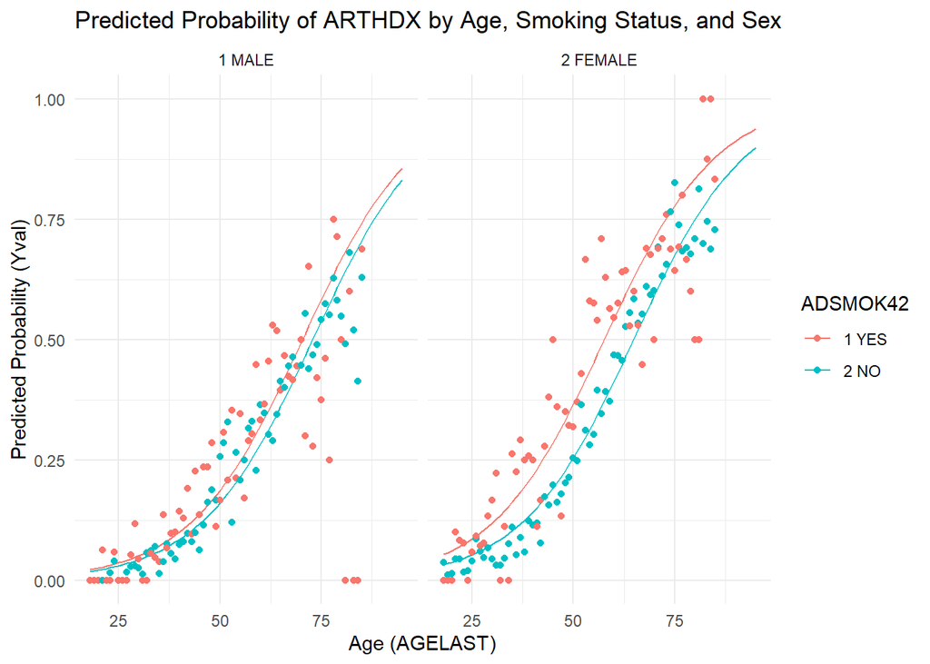

```r
# Creating the prediction data frame
prediction <- expand.grid(SEX = c("1 MALE", "2 FEMALE"), ADSMOK42 = c("1 YES", "2 NO"), AGELAST = seq(18, 95))

# Predicting values using the model
prediction$Yval <- predict(fit, newdata = prediction, type = "response")


# Plotting the results
ggplot(prediction, aes(x = AGELAST, y = Yval, col = ADSMOK42)) +
  geom_line() +
  geom_point(data = data_point, aes(y = frequency)) +
  facet_wrap(~SEX) +
  labs(title = "Predicted Probability of ARTHDX by Age, Smoking Status, and Sex",
       x = "Age (AGELAST)",
       y = "Predicted Probability (Yval)") +
  theme_minimal()
```

All our variables are significant. Arthritis is characterized by a positive correlation with smoking (more pronounced in women), sex and age.

### 2.1.2 Diabetes

```r
filter_df <- small_df %>% select(DIABDX_M18, ADSMOK42, SEX, AGELAST, AGEGROUP) %>% filter(rowSums(sapply(., function(x) x %in% values_to_remove)) == 0)

# filter_df <- filter_df %>% filter(AGEGROUP == "65+")

filter_df$DIABDX_M18 <- relevel(filter_df$DIABDX_M18, ref = "2 NO")
filter_df$ADSMOK42 <- relevel(filter_df$ADSMOK42, ref = "2 NO")
filter_df$SEX <- relevel(filter_df$SEX, ref = "1 MALE")

fit <- glm(DIABDX_M18 ~ ADSMOK42 * SEX + AGELAST, data = filter_df, family = "binomial")

summary(fit)
```

```
##
## Call:
## glm(formula = DIABDX_M18 ~ ADSMOK42 * SEX + AGELAST, family = "binomial",
##     data = filter_df)
##
## Coefficients:
##                            Estimate Std. Error z value Pr(>|z|)
## (Intercept)               -4.201238   0.101001 -41.596  < 2e-16 ***
## ADSMOK421 YES              0.029254   0.087979   0.333 0.739500
## SEX2 FEMALE               -0.152259   0.051660  -2.947 0.003205 **
## AGELAST                    0.043263   0.001486  29.117  < 2e-16 ***
## ADSMOK421 YES:SEX2 FEMALE  0.408440   0.117066   3.489 0.000485 ***
## ---
## Signif. codes:  0 '***' 0.001 '**' 0.01 '*' 0.05 '.' 0.1 ' ' 1
##
## (Dispersion parameter for binomial family taken to be 1)
##
##     Null deviance: 13262  on 15417  degrees of freedom
## Residual deviance: 12230  on 15413  degrees of freedom
## AIC: 12240
##
## Number of Fisher Scoring iterations: 5
```

```r
data_point <- filter_df %>%  group_by(AGEGROUP,AGELAST, SEX, ADSMOK42) %>% summarise(WithCancer = sum(DIABDX_M18 == "1 YES"), tot = n()) %>%
  mutate(frequency = WithCancer/tot)
```

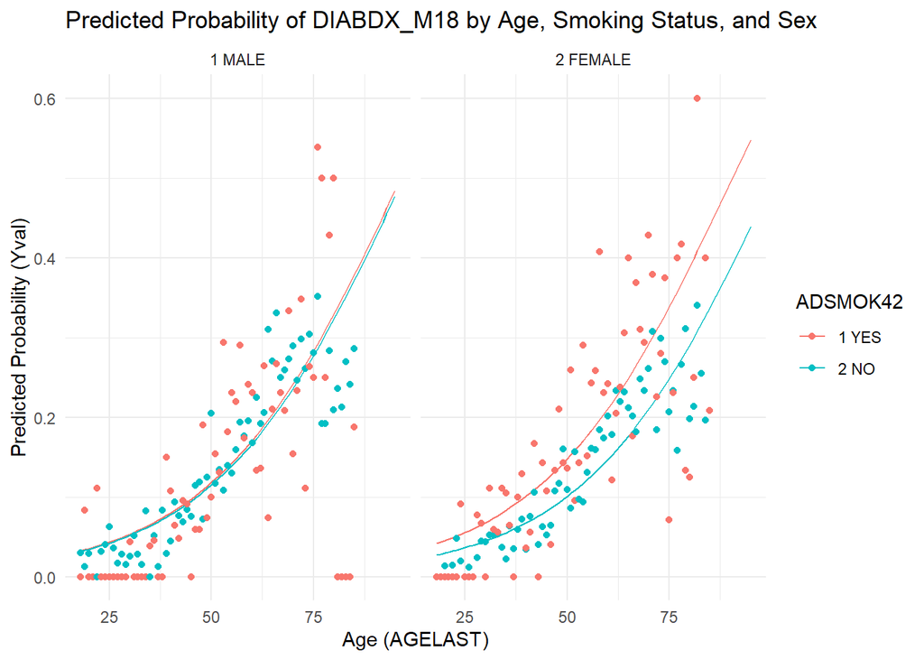

```r
# Creating the prediction data frame
prediction <- expand.grid(SEX = c("1 MALE", "2 FEMALE"), ADSMOK42 = c("1 YES", "2 NO"), AGELAST = seq(18, 95))

# Predicting values using the model
prediction$Yval <- predict(fit, newdata = prediction, type = "response")


# Plotting the results
ggplot(prediction, aes(x = AGELAST, y = Yval, col = ADSMOK42)) +
  geom_line() +
  geom_point(data = data_point, aes(y = frequency)) +
  facet_wrap(~SEX) +
  labs(title = "Predicted Probability of DIABDX_M18 by Age, Smoking Status, and Sex",
       x = "Age (AGELAST)",
       y = "Predicted Probability (Yval)") +
  theme_minimal()+
  ylim(c(0, 0.6))
```

In this case, looking at smoking in general is not significant, but if we control for sex, in the female there is definitely a correlation. Diabetes is characterized by a positive correlation with smoking (significant in women) and with age, and a negative one with being female.

### 2.1.3 Emphysema

```r
filter_df <- small_df %>% select(EMPHDX, ADSMOK42, SEX, AGELAST, AGEGROUP) %>% filter(rowSums(sapply(., function(x) x %in% values_to_remove)) == 0)

# filter_df <- filter_df %>% filter(AGEGROUP == "65+")

filter_df$EMPHDX <- relevel(filter_df$EMPHDX, ref = "2 NO")
filter_df$ADSMOK42 <- relevel(filter_df$ADSMOK42, ref = "2 NO")
filter_df$SEX <- relevel(filter_df$SEX, ref = "1 MALE")

fit <- glm(EMPHDX ~ ADSMOK42 * SEX + AGELAST, data = filter_df, family = "binomial")

summary(fit)
```

```
##
## Call:
## glm(formula = EMPHDX ~ ADSMOK42 * SEX + AGELAST, family = "binomial",
##     data = filter_df)
##
## Coefficients:
##                            Estimate Std. Error z value Pr(>|z|)
## (Intercept)               -7.777000   0.307674 -25.277  < 2e-16 ***
## ADSMOK421 YES              1.104037   0.169023   6.532  6.5e-11 ***
## SEX2 FEMALE               -0.366242   0.141096  -2.596  0.00944 **
## AGELAST                    0.061537   0.004193  14.675  < 2e-16 ***
## ADSMOK421 YES:SEX2 FEMALE  0.644011   0.224886   2.864  0.00419 **
## ---
## Signif. codes:  0 '***' 0.001 '**' 0.01 '*' 0.05 '.' 0.1 ' ' 1
##
## (Dispersion parameter for binomial family taken to be 1)
##
##     Null deviance: 3400.4  on 15388  degrees of freedom
## Residual deviance: 2994.3  on 15384  degrees of freedom
## AIC: 3004.3
##
## Number of Fisher Scoring iterations: 7
```

```r
data_point <- filter_df %>%  group_by(AGEGROUP,AGELAST, SEX, ADSMOK42) %>% summarise(WithCancer = sum(EMPHDX == "1 YES"), tot = n()) %>%
  mutate(frequency = WithCancer/tot)
```

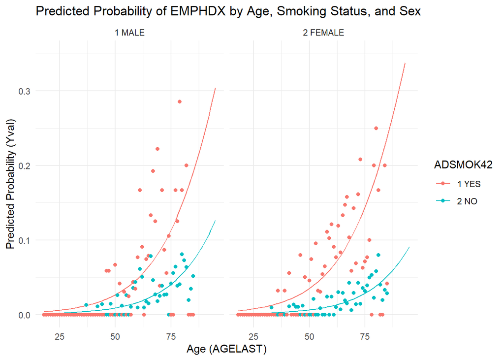

```r
# Creating the prediction data frame
prediction <- expand.grid(SEX = c("1 MALE", "2 FEMALE"), ADSMOK42 = c("1 YES", "2 NO"), AGELAST = seq(18, 95))

# Predicting values using the model
prediction$Yval <- predict(fit, newdata = prediction, type = "response")


# Plotting the results
ggplot(prediction, aes(x = AGELAST, y = Yval, col = ADSMOK42)) +
  geom_line() +
  geom_point(data = data_point, aes(y = frequency)) +
  facet_wrap(~SEX) +
  labs(title = "Predicted Probability of EMPHDX by Age, Smoking Status, and Sex",
       x = "Age (AGELAST)",
       y = "Predicted Probability (Yval)") +
  theme_minimal()+
  ylim(c(0, 0.35))
```

All our variables are significant. Emphysema is characterized by a positive correlation with smoking and age (more pronounced in smokers), and a negative one for being female.

### 2.1.4 Stroke

```r
filter_df <- small_df %>% select(STRKDX, ADSMOK42, SEX, AGELAST, AGEGROUP) %>% filter(rowSums(sapply(., function(x) x %in% values_to_remove)) == 0)

# filter_df <- filter_df %>% filter(AGEGROUP == "65+")

filter_df$STRKDX <- relevel(filter_df$STRKDX, ref = "2 NO")
filter_df$ADSMOK42 <- relevel(filter_df$ADSMOK42, ref = "2 NO")
filter_df$SEX <- relevel(filter_df$SEX, ref = "1 MALE")

fit <- glm(STRKDX ~ ADSMOK42 * SEX + AGELAST, data = filter_df, family = "binomial")

summary(fit)
```

```
##
## Call:
## glm(formula = STRKDX ~ ADSMOK42 * SEX + AGELAST, family = "binomial",
##     data = filter_df)
##
## Coefficients:
##                            Estimate Std. Error z value Pr(>|z|)
## (Intercept)               -6.584584   0.195221 -33.729  < 2e-16 ***
## ADSMOK421 YES              0.540824   0.125410   4.312 1.61e-05 ***
## SEX2 FEMALE               -0.196109   0.083610  -2.346    0.019 *
## AGELAST                    0.060109   0.002713  22.155  < 2e-16 ***
## ADSMOK421 YES:SEX2 FEMALE  0.240915   0.168872   1.427    0.154
## ---
## Signif. codes:  0 '***' 0.001 '**' 0.01 '*' 0.05 '.' 0.1 ' ' 1
##
## (Dispersion parameter for binomial family taken to be 1)
##
##     Null deviance: 6558.6  on 15388  degrees of freedom
## Residual deviance: 5871.2  on 15384  degrees of freedom
## AIC: 5881.2
##
## Number of Fisher Scoring iterations: 6
```

```r
data_point <- filter_df %>%  group_by(AGEGROUP,AGELAST, SEX, ADSMOK42) %>% summarise(WithCancer = sum(STRKDX == "1 YES"), tot = n()) %>%
  mutate(frequency = WithCancer/tot)
```

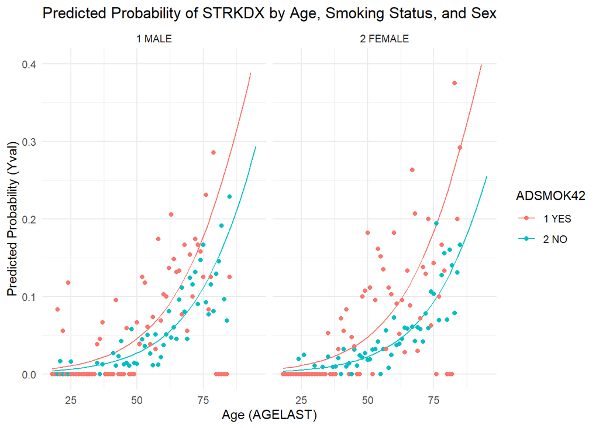

```r
# Creating the prediction data frame
prediction <- expand.grid(SEX = c("1 MALE", "2 FEMALE"), ADSMOK42 = c("1 YES", "2 NO"), AGELAST = seq(18, 95))

# Predicting values using the model
prediction$Yval <- predict(fit, newdata = prediction, type = "response")


# Plotting the results
ggplot(prediction, aes(x = AGELAST, y = Yval, col = ADSMOK42)) +
  geom_line() +
  geom_point(data = data_point, aes(y = frequency)) +
  facet_wrap(~SEX) +
  labs(title = "Predicted Probability of STRKDX by Age, Smoking Status, and Sex",
       x = "Age (AGELAST)",
       y = "Predicted Probability (Yval)") +
  theme_minimal()+
  ylim(c(0, 0.4))
```

All our variables are significant, except for the interaction between smoking and sex. Stroke is characterized by a positive correlation with smoking and age, and a negative one for being female.

### 2.1.5 Lung Cancer

```r
filter_df <- small_df %>% select(CALUNG, ADSMOK42, SEX, AGELAST, AGEGROUP) %>% filter(rowSums(sapply(., function(x) x %in% values_to_remove)) == 0)

# filter_df <- filter_df %>% filter(AGEGROUP == "65+")

filter_df$CALUNG <- relevel(filter_df$CALUNG, ref = "2 NO")
filter_df$ADSMOK42 <- relevel(filter_df$ADSMOK42, ref = "2 NO")
filter_df$SEX <- relevel(filter_df$SEX, ref = "1 MALE")

fit <- glm(CALUNG ~ ADSMOK42 * SEX + AGELAST, data = filter_df, family = "binomial")

summary(fit)
```

```
##
## Call:
## glm(formula = CALUNG ~ ADSMOK42 * SEX + AGELAST, family = "binomial",
##     data = filter_df)
##
## Coefficients:
##                           Estimate Std. Error z value Pr(>|z|)
## (Intercept)               -6.06890    0.96416  -6.295 3.08e-10 ***
## ADSMOK421 YES              1.27743    0.44114   2.896  0.00378 **
## SEX2 FEMALE                0.24805    0.30244   0.820  0.41212
## AGELAST                    0.03153    0.01263   2.497  0.01252 *
## ADSMOK421 YES:SEX2 FEMALE -0.96393    0.63175  -1.526  0.12706
## ---
## Signif. codes:  0 '***' 0.001 '**' 0.01 '*' 0.05 '.' 0.1 ' ' 1
##
## (Dispersion parameter for binomial family taken to be 1)
##
##     Null deviance: 566.73  on 2233  degrees of freedom
## Residual deviance: 553.81  on 2229  degrees of freedom
## AIC: 563.81
##
## Number of Fisher Scoring iterations: 6
```

```r
data_point <- filter_df %>%  group_by(AGEGROUP,AGELAST, SEX, ADSMOK42) %>% summarise(WithCancer = sum(CALUNG == "1 YES"), tot = n()) %>%
  mutate(frequency = WithCancer/tot)
```

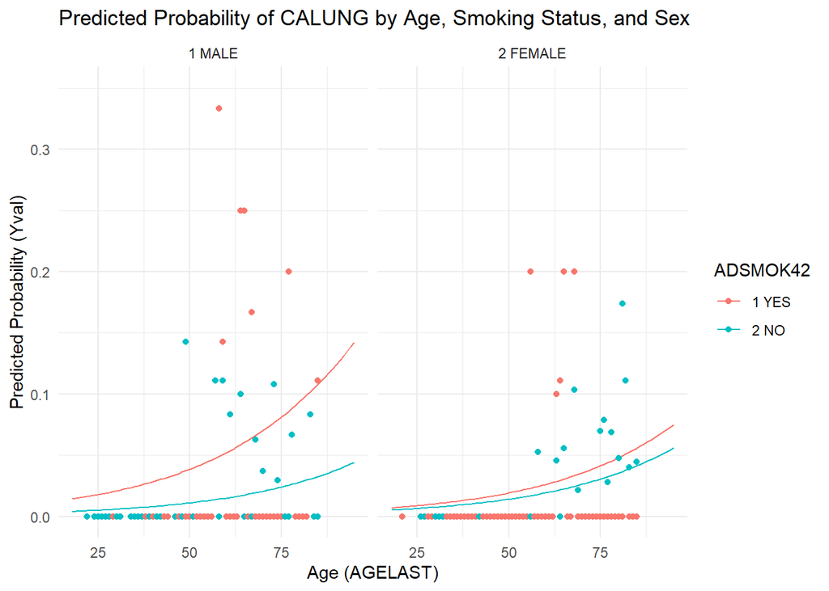

```r
# Creating the prediction data frame
prediction <- expand.grid(SEX = c("1 MALE", "2 FEMALE"), ADSMOK42 = c("1 YES", "2 NO"), AGELAST = seq(18, 95))

# Predicting values using the model
prediction$Yval <- predict(fit, newdata = prediction, type = "response")


# Plotting the results
ggplot(prediction, aes(x = AGELAST, y = Yval, col = ADSMOK42)) +
  geom_line() +
  geom_point(data = data_point, aes(y = frequency)) +
  facet_wrap(~SEX) +
  labs(title = "Predicted Probability of CALUNG by Age, Smoking Status, and Sex",
       x = "Age (AGELAST)",
       y = "Predicted Probability (Yval)") +
  theme_minimal()+
  ylim(c(0, 0.35))
```

### 2.1.6 Asthma

```r
filter_df <- small_df %>% select(ASTHDX, ADSMOK42, SEX, AGELAST, AGEGROUP) %>% filter(rowSums(sapply(., function(x) x %in% values_to_remove)) == 0)

# filter_df <- filter_df %>% filter(AGEGROUP == c("18-24"))

filter_df$ASTHDX <- relevel(filter_df$ASTHDX, ref = "2 NO")
filter_df$ADSMOK42 <- relevel(filter_df$ADSMOK42, ref = "2 NO")
filter_df$SEX <- relevel(filter_df$SEX, ref = "1 MALE")


fit <- glm(ASTHDX ~ ADSMOK42 * SEX + AGELAST, data = filter_df, family = "binomial")

summary(fit)
```

```
##
## Call:
## glm(formula = ASTHDX ~ ADSMOK42 * SEX + AGELAST, family = "binomial",
##     data = filter_df)
##
## Coefficients:
##                            Estimate Std. Error z value Pr(>|z|)
## (Intercept)               -1.671965   0.076252 -21.927  < 2e-16 ***
## ADSMOK421 YES              0.041146   0.089118   0.462  0.64430
## SEX2 FEMALE                0.285653   0.051757   5.519 3.41e-08 ***
## AGELAST                   -0.004836   0.001230  -3.933 8.38e-05 ***
## ADSMOK421 YES:SEX2 FEMALE  0.313916   0.114266   2.747  0.00601 **
## ---
## Signif. codes:  0 '***' 0.001 '**' 0.01 '*' 0.05 '.' 0.1 ' ' 1
##
## (Dispersion parameter for binomial family taken to be 1)
##
##     Null deviance: 13120  on 15420  degrees of freedom
## Residual deviance: 13025  on 15416  degrees of freedom
## AIC: 13035
##
## Number of Fisher Scoring iterations: 4
```

```r
data_point <- filter_df %>%  group_by(AGEGROUP,AGELAST, SEX, ADSMOK42) %>% summarise(WithAsthma = sum(ASTHDX == "1 YES"), tot = n()) %>%
  mutate(frequency = WithAsthma/tot)
```

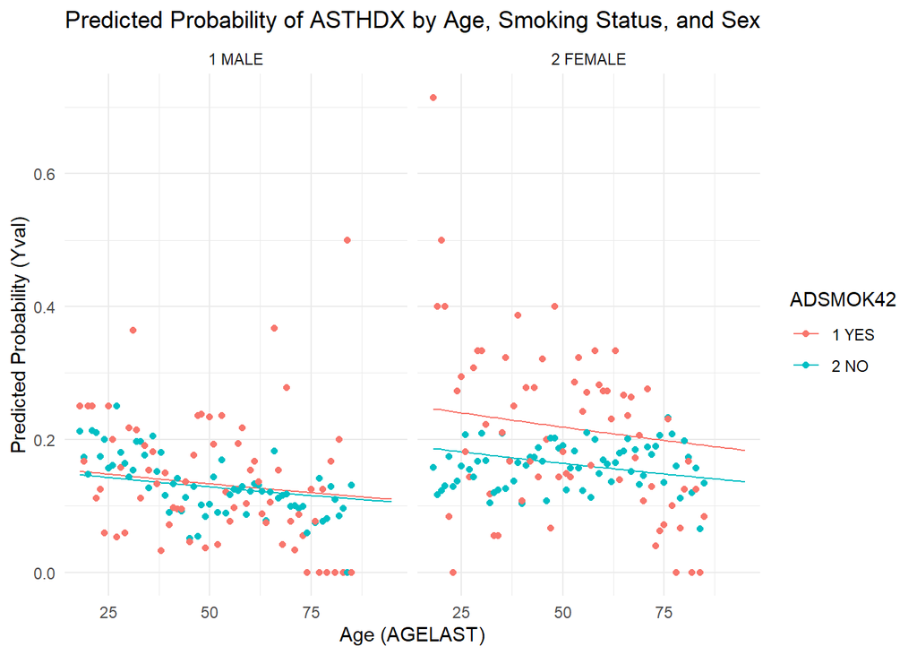

```r
prediction <- expand.grid(SEX = c("1 MALE", "2 FEMALE"), ADSMOK42 = c("1 YES", "2 NO"), AGELAST = seq(18, 95))

# Predicting values using the model
prediction$Yval <- predict(fit, newdata = prediction, type = "response")


# Plotting the results
ggplot(prediction, aes(x = AGELAST, y = Yval, col = ADSMOK42)) +
  geom_line() +
  geom_point(data = data_point, aes(y = frequency)) +
  facet_wrap(~SEX) +
  labs(title = "Predicted Probability of ASTHDX by Age, Smoking Status, and Sex",
       x = "Age (AGELAST)",
       y = "Predicted Probability (Yval)") +
  theme_minimal()+
  theme(plot.title = element_text(hjust = 0.5))
```

Also in this case, looking at smoking in general is not significant, but if we look at the interaction between smoking and sex, there is definitely a correlation. Asthma is quite particular, because is the only one that is characterized by a negative correlation with age. Also in this case we have a positive correlation with smoking (significant in female) and with sex.

### 2.1.7 High Cholesterol

```r
filter_df <- small_df %>% select(CHOLDX, ADSMOK42, SEX, AGELAST, AGEGROUP) %>% filter(rowSums(sapply(., function(x) x %in% values_to_remove)) == 0)

# filter_df <- filter_df %>% filter(AGEGROUP == "65+")

filter_df$CHOLDX <- relevel(filter_df$CHOLDX, ref = "2 NO")
filter_df$ADSMOK42 <- relevel(filter_df$ADSMOK42, ref = "2 NO")
filter_df$SEX <- relevel(filter_df$SEX, ref = "1 MALE")


fit <- glm(CHOLDX ~ ADSMOK42 * SEX + AGELAST, data = filter_df, family = "binomial")

summary(fit)
```

```
##
## Call:
## glm(formula = CHOLDX ~ ADSMOK42 * SEX + AGELAST, family = "binomial",
##     data = filter_df)
##
## Coefficients:
##                            Estimate Std. Error z value Pr(>|z|)
## (Intercept)               -3.744208   0.075692 -49.466  < 2e-16 ***
## ADSMOK421 YES              0.060372   0.068518   0.881 0.378254
## SEX2 FEMALE               -0.174565   0.041336  -4.223 2.41e-05 ***
## AGELAST                    0.059723   0.001189  50.227  < 2e-16 ***
## ADSMOK421 YES:SEX2 FEMALE  0.317587   0.093992   3.379 0.000728 ***
## ---
## Signif. codes:  0 '***' 0.001 '**' 0.01 '*' 0.05 '.' 0.1 ' ' 1
##
## (Dispersion parameter for binomial family taken to be 1)
##
##     Null deviance: 20600  on 15380  degrees of freedom
## Residual deviance: 17303  on 15376  degrees of freedom
## AIC: 17313
##
## Number of Fisher Scoring iterations: 4
```

```r
data_point <- filter_df %>%  group_by(AGELAST, SEX, ADSMOK42) %>% summarise(WithChol = sum(CHOLDX == "1 YES"), tot = n()) %>%
  mutate(frequency = WithChol/tot)
```

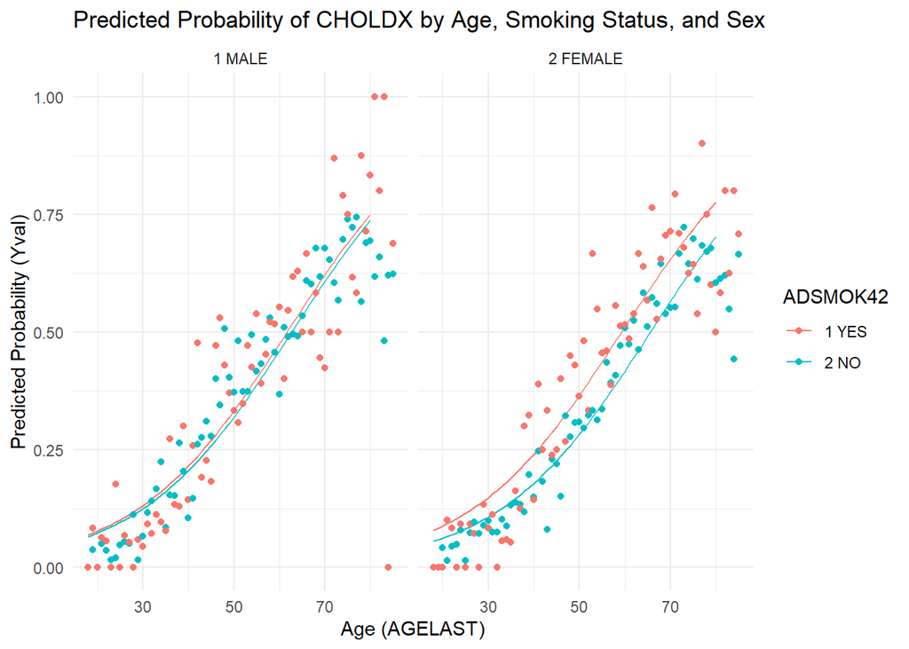

```r
prediction <- expand.grid(SEX = c("1 MALE", "2 FEMALE"), ADSMOK42 = c("1 YES", "2 NO"), AGELAST = seq(18, 80))


prediction$Yval <- predict(fit, newdata = prediction, type = "response")

ggplot(prediction, aes(x = AGELAST, y = Yval, col = ADSMOK42)) +
  geom_line() +
  geom_point(data = data_point, aes(y = frequency)) +
  facet_wrap(~SEX) +
  labs(title = "Predicted Probability of CHOLDX by Age, Smoking Status, and Sex",
       x = "Age (AGELAST)",
       y = "Predicted Probability (Yval)") +
  theme_minimal()
```

Also in this case, looking at smoking in general is not significant, as we see in the interaction with sex, in the female there is definitely a correlation. High Cholesterol is characterized by a positive correlation with smoking (significant in women) and with age, and a negative one with being female.

### 2.1.8 Chronic Bronchitis

```r
filter_df <- small_df %>% select(CHBRON31, ADSMOK42, SEX, AGELAST, AGEGROUP) %>% filter(rowSums(sapply(., function(x) x %in% values_to_remove)) == 0)


# filter_df <- filter_df %>% filter(AGEGROUP == "65+")

filter_df$CHBRON31 <- relevel(filter_df$CHBRON31, ref = "2 NO")
filter_df$ADSMOK42 <- relevel(filter_df$ADSMOK42, ref = "2 NO")
filter_df$SEX <- relevel(filter_df$SEX, ref = "1 MALE")


fit <- glm(CHBRON31 ~ ADSMOK42 * SEX + AGELAST, data = filter_df, family = "binomial")

summary(fit)
```

```
##
## Call:
## glm(formula = CHBRON31 ~ ADSMOK42 * SEX + AGELAST, family = "binomial",
##     data = filter_df)
##
## Coefficients:
##                            Estimate Std. Error z value Pr(>|z|)
## (Intercept)               -5.540038   0.261348 -21.198  < 2e-16 ***
## ADSMOK421 YES              0.383047   0.261141   1.467   0.1424
## SEX2 FEMALE                0.399067   0.161999   2.463   0.0138 *
## AGELAST                    0.017757   0.003786   4.690 2.73e-06 ***
## ADSMOK421 YES:SEX2 FEMALE  0.576253   0.308866   1.866   0.0621 .
## ---
## Signif. codes:  0 '***' 0.001 '**' 0.01 '*' 0.05 '.' 0.1 ' ' 1
##
## (Dispersion parameter for binomial family taken to be 1)
##
##     Null deviance: 2537.5  on 15328  degrees of freedom
## Residual deviance: 2467.1  on 15324  degrees of freedom
## AIC: 2477.1
##
## Number of Fisher Scoring iterations: 7
```

```r
data_point <- filter_df %>%  group_by(AGELAST, SEX, ADSMOK42) %>% summarise(WithBronch = sum(CHBRON31 == "1 YES"), tot = n()) %>%
  mutate(frequency = WithBronch/tot)
```

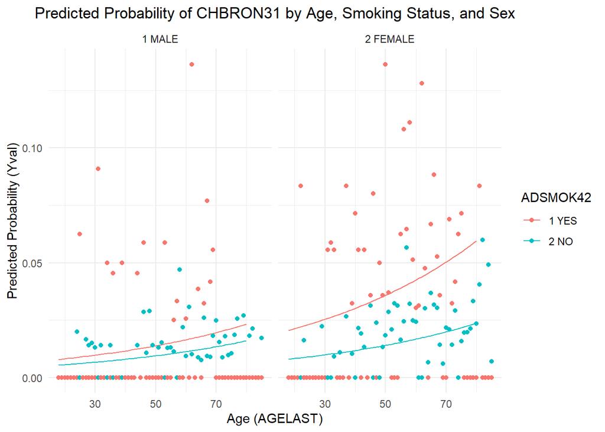

```r
# Creating the prediction data frame
df_pred <- expand.grid(SEX = c("1 MALE", "2 FEMALE"), ADSMOK42 = c("1 YES", "2 NO"), AGELAST = seq(18, 80))

# Predicting values using the model
df_pred$Yval <- predict(fit, newdata = df_pred, type = "response")


# Plotting the results
ggplot(df_pred, aes(x = AGELAST, y = Yval, col = ADSMOK42)) +
  geom_line() +
  geom_point(data = data_point, aes(y = frequency)) +
  facet_wrap(~SEX) +
  labs(title = "Predicted Probability of CHBRON31 by Age, Smoking Status, and Sex",
       x = "Age (AGELAST)",
       y = "Predicted Probability (Yval)") +
  theme_minimal()+
  theme(plot.title = element_text(hjust = 0.5))
```

### 2.1.9 High Blood Pressure

```r
filter_df <- small_df %>% select(HIBPDX, ADSMOK42, SEX, AGELAST) %>% filter(rowSums(sapply(., function(x) x %in% values_to_remove)) == 0)

# filter_df <- filter_df %>% filter(AGEGROUP == "65+")

filter_df$HIBPDX <- relevel(filter_df$HIBPDX, ref = "2 NO")
filter_df$ADSMOK42 <- relevel(filter_df$ADSMOK42, ref = "2 NO")
filter_df$SEX <- relevel(filter_df$SEX, ref = "1 MALE")


fit <- glm(HIBPDX ~ ADSMOK42 * SEX + AGELAST, data = filter_df, family = "binomial")

summary(fit)
```

```
##
## Call:
## glm(formula = HIBPDX ~ ADSMOK42 * SEX + AGELAST, family = "binomial",
##     data = filter_df)
##
## Coefficients:
##                            Estimate Std. Error z value Pr(>|z|)
## (Intercept)               -3.972786   0.077436 -51.304  < 2e-16 ***
## ADSMOK421 YES              0.250575   0.068732   3.646 0.000267 ***
## SEX2 FEMALE               -0.230722   0.041966  -5.498 3.84e-08 ***
## AGELAST                    0.065871   0.001229  53.612  < 2e-16 ***
## ADSMOK421 YES:SEX2 FEMALE  0.189444   0.094694   2.001 0.045437 *
## ---
## Signif. codes:  0 '***' 0.001 '**' 0.01 '*' 0.05 '.' 0.1 ' ' 1
##
## (Dispersion parameter for binomial family taken to be 1)
##
##     Null deviance: 20879  on 15382  degrees of freedom
## Residual deviance: 16958  on 15378  degrees of freedom
## AIC: 16968
##
## Number of Fisher Scoring iterations: 4
```

```r
data_point <- filter_df %>%  group_by(AGELAST, SEX, ADSMOK42) %>% summarise(WithPress = sum(HIBPDX == "1 YES"), tot = n()) %>%
  mutate(frequency = WithPress/tot)
```

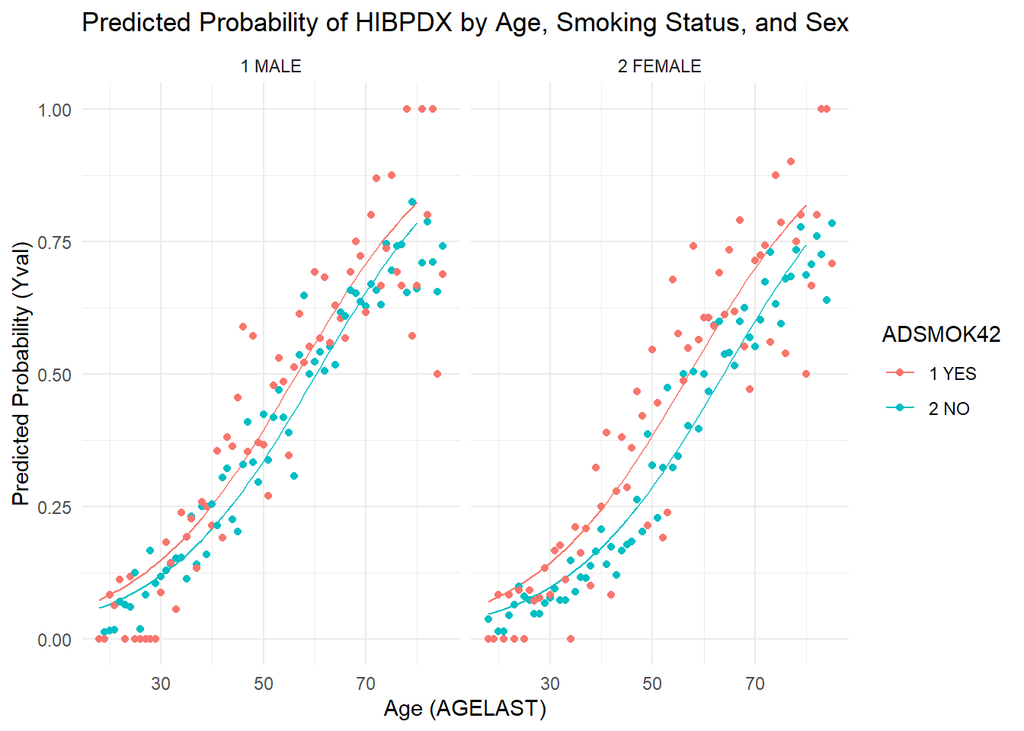

```r
# Creating the prediction data frame
df_pred <- expand.grid(SEX = c("1 MALE", "2 FEMALE"), ADSMOK42 = c("1 YES", "2 NO"), AGELAST = seq(18, 80))

# Predicting values using the model
df_pred$Yval <- predict(fit, newdata = df_pred, type = "response")


# Plotting the results
ggplot(df_pred, aes(x = AGELAST, y = Yval, col = ADSMOK42)) +
  geom_line() +
  geom_point(data = data_point, aes(y = frequency)) +
  facet_wrap(~SEX) +
  labs(title = "Predicted Probability of HIBPDX by Age, Smoking Status, and Sex",
       x = "Age (AGELAST)",
       y = "Predicted Probability (Yval)") +
  theme_minimal()+
  theme(plot.title = element_text(hjust = 0.5))
```

In this case, all our variables are significant. High Blood Pressure is characterized by a positive correlation with smoking and with age, and a negative one with being female.

As we can say we obtained a lot of different results, both negative and positive, but we can see that for some models there is a direct correlation with *AGE*. Also some plots are quite similar (like the one for Cholesterol and Blood pressure) So there could be some connection between those disease. To prove this we can try if some physical diseases have some of connection.

#### 2.1.9.1 Trying to see if Cholesterol and Blood pressure are correlated

```r
filter_df <- small_df %>% select(CHOLDX, HIBPDX, ADSMOK42, SEX, AGELAST, AGEGROUP) %>% filter(rowSums(sapply(., function(x) x %in% values_to_remove)) == 0)

# filter_df <- filter_df %>% filter(AGEGROUP == "65+")

filter_df$HIBPDX <- relevel(filter_df$HIBPDX, ref = "2 NO")
filter_df$CHOLDX <- relevel(filter_df$CHOLDX, ref = "2 NO")
filter_df$ADSMOK42 <- relevel(filter_df$ADSMOK42, ref = "2 NO")
filter_df$SEX <- relevel(filter_df$SEX, ref = "1 MALE")


fit <- glm(CHOLDX ~ HIBPDX * SEX + AGELAST, data = filter_df, family = "binomial")

summary(fit)
```

```
##
## Call:
## glm(formula = CHOLDX ~ HIBPDX * SEX + AGELAST, family = "binomial",
##     data = filter_df)
##
## Coefficients:
##                          Estimate Std. Error z value Pr(>|z|)
## (Intercept)             -3.581089   0.079307 -45.155   <2e-16 ***
## HIBPDX1 YES              1.370965   0.058465  23.449   <2e-16 ***
## SEX2 FEMALE              0.004253   0.054612   0.078   0.9379
## AGELAST                  0.045294   0.001271  35.642   <2e-16 ***
## HIBPDX1 YES:SEX2 FEMALE -0.152694   0.077325  -1.975   0.0483 *
## ---
## Signif. codes:  0 '***' 0.001 '**' 0.01 '*' 0.05 '.' 0.1 ' ' 1
##
## (Dispersion parameter for binomial family taken to be 1)
##
##     Null deviance: 20594  on 15375  degrees of freedom
## Residual deviance: 16282  on 15371  degrees of freedom
## AIC: 16292
##
## Number of Fisher Scoring iterations: 4
```

```r
data_point <- filter_df %>%  group_by(AGELAST, SEX, HIBPDX) %>% summarise(WithChol = sum(CHOLDX == "1 YES"), tot = n()) %>%
  mutate(frequency = WithChol/tot)
```

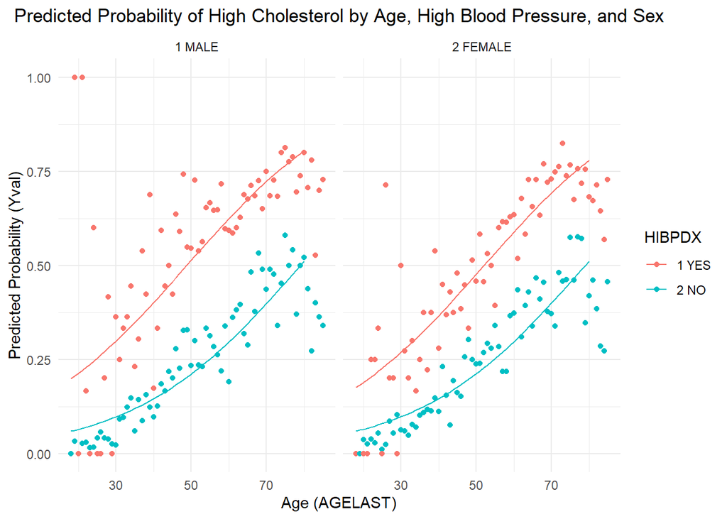

```r
prediction <- expand.grid(SEX = c("1 MALE", "2 FEMALE"), HIBPDX = c("1 YES", "2 NO"), AGELAST = seq(18, 80))


prediction$Yval <- predict(fit, newdata = prediction, type = "response")

ggplot(prediction, aes(x = AGELAST, y = Yval, col = HIBPDX)) +
  geom_line() +
  geom_point(data = data_point, aes(y = frequency)) +
  facet_wrap(~SEX) +
  labs(title = "Predicted Probability of High Cholesterol by Age, High Blood Pressure, and Sex",
       x = "Age (AGELAST)",
       y = "Predicted Probability (Yval)") +
  theme_minimal()+
  theme(plot.title = element_text(hjust = 0.5))
```

As we can see, there is definitely a correlation.

## 2.2 Multilogit regression for Mental Health

Now to evaluate the mental health status we need to change the type of the regression. In the first part we used the Logistic Regression, but for this part we need to use the Multinomial Logistic Regression. MLR is a classification method that modify logistic regression to multiclass problems, i.e. with more than two possible discrete outcomes (I promise, is just a case that is very similar to the Wikipedia description).

### 2.2.1 Perceived Mental Health Status

```r
filter_df <-small_df %>% select(MNHLTH31, ADSMOK42, SEX, AGELAST) %>% filter(rowSums(sapply(., function(x) x %in% values_to_remove)) == 0)

# filter_df <- filter_df %>% filter(AGEGROUP == "65+")

filter_df$MNHLTH31 <- relevel(filter_df$MNHLTH31, ref = "1 EXCELLENT")
filter_df$ADSMOK42 <- relevel(filter_df$ADSMOK42, ref = "2 NO")
filter_df$SEX <- relevel(filter_df$SEX, ref = "1 MALE")
filter_df$MNHLTH31 = ordered(filter_df$MNHLTH31)
```

```r
fit <- vglm(MNHLTH31 ~ AGELAST,
             family = cumulative(parallel = TRUE),
             data = filter_df)

df_pred <- expand.grid(SEX = c("1 MALE", "2 FEMALE"), ADSMOK42 = c("1 YES", "2 NO"), AGELAST = seq(18, 80))


matplot(df_pred$AGELAST, predict(fit, df_pred,type = "response"), type = "l",
        ylab = "Predicted Probability", xlab = "Age", lwd = 2) +
  title("Mental Health by Age") +
  grid()
```

```
## integer(0)
```

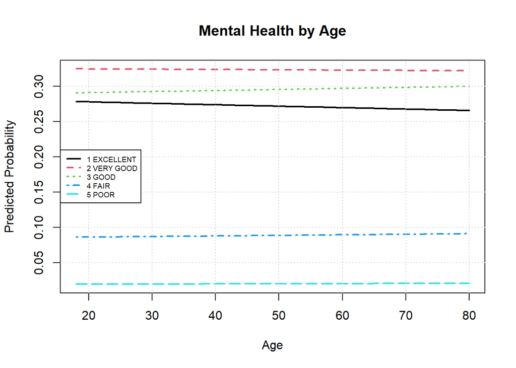

```r
legend("left",legend = sort(unique(filter_df$MNHLTH31)), col = 1:5, lty = 1:5, lwd = 2, cex = 0.6)
```

Here we can see the general distribution of the Perceived Mental Health Status for every age. As we see, the majority of the people are distributed between the 3 best cases, with the “very good” one being the most frequent.

```r
null <-  vglm(MNHLTH31 ~ 1,
             family = cumulative(parallel = TRUE),
             data = filter_df)

pchisq(deviance(null)-deviance(fit), df <- df.residual(null)-df.residual(fit), lower.tail=FALSE)
```

```
## [1] 0.194099
```

Then we fitted the model with also SEX

```r
fit <- vglm(MNHLTH31 ~ ADSMOK42 + SEX + AGELAST,
             family = cumulative(parallel = TRUE),
             data = filter_df)
summary(fit)
```

```
##
## Call:
## vglm(formula = MNHLTH31 ~ ADSMOK42 + SEX + AGELAST, family = cumulative(parallel = TRUE),
##     data = filter_df)
##
## Coefficients:
##                 Estimate Std. Error z value Pr(>|z|)
## (Intercept):1 -0.6862955  0.0494676 -13.874   <2e-16 ***
## (Intercept):2  0.7047961  0.0494543  14.251   <2e-16 ***
## (Intercept):3  2.4488090  0.0539677  45.375   <2e-16 ***
## (Intercept):4  4.2516580  0.0747581  56.872   <2e-16 ***
## ADSMOK421 YES -0.6026349  0.0379176 -15.893   <2e-16 ***
## SEX2 FEMALE   -0.2528145  0.0293955  -8.600   <2e-16 ***
## AGELAST       -0.0013227  0.0007976  -1.658   0.0972 .
## ---
## Signif. codes:  0 '***' 0.001 '**' 0.01 '*' 0.05 '.' 0.1 ' ' 1
##
## Names of linear predictors: logitlink(P[Y<=1]), logitlink(P[Y<=2]),
## logitlink(P[Y<=3]), logitlink(P[Y<=4])
##
## Residual deviance: 41991.95 on 61629 degrees of freedom
##
## Log-likelihood: -20995.97 on 61629 degrees of freedom
##
## Number of Fisher scoring iterations: 4
##
## Warning: Hauck-Donner effect detected in the following estimate(s):
## '(Intercept):4'
##
##
## Exponentiated coefficients:
## ADSMOK421 YES   SEX2 FEMALE       AGELAST
##     0.5473675     0.7766120     0.9986782
```

Oh no! There is a problem in our regression, what is that? The Hauck-Donner effect? It reminds me a name of a music instrument brand…never mind.

The Hauck-Donner effect is a problem that can occur if we use small data-frame, indicates that the significance of our model can be false. But how can we solve it? Don’t worry, is very simple.

We bootstrapped the original data-frame for 100 times (better more but our pc are not so powerful).

```r
data <- filter_df
formula <- MNHLTH31 ~ ADSMOK42 + SEX + AGELAST

fit_model <- function(data, indices) {
  boot_data <- data[indices, ]
  model <- vglm(formula,
             family = cumulative(parallel = TRUE),
             data = boot_data)
  return(coef(model))
}

set.seed(123)
bootstrap_results <- boot(data = data, statistic = fit_model, R = 100)

bootstrap_results
```

```
##
## ORDINARY NONPARAMETRIC BOOTSTRAP
##
##
## Call:
## boot(data = data, statistic = fit_model, R = 100)
##
##
## Bootstrap Statistics :
##         original        bias     std. error
## t1* -0.686295534  8.293538e-04 0.0481159045
## t2*  0.704796145  2.315522e-03 0.0512439628
## t3*  2.448809015  4.123762e-03 0.0553600060
## t4*  4.251657965  4.672130e-03 0.0857172943
## t5* -0.602634909 -2.362184e-03 0.0409388089
## t6* -0.252814473 -5.483153e-04 0.0285605837
## t7* -0.001322697 -1.281613e-06 0.0008524966
```

```r
boot.ci(bootstrap_results, type = "basic")
```

```
## BOOTSTRAP CONFIDENCE INTERVAL CALCULATIONS
## Based on 100 bootstrap replicates
##
## CALL :
## boot.ci(boot.out = bootstrap_results, type = "basic")
##
## Intervals :
## Level      Basic
## 95%   (-0.7822, -0.5829 )
## Calculations and Intervals on Original Scale
## Some basic intervals may be unstable
```

Fortunately the bootstrap confirm the robustness of our model.

#### 2.2.1.1 Difference between smokers and non smokers

Then we compared the smokers and non smokers filtering the dataset for this variable and fitting 2 models.

```r
smk_df = filter_df %>% filter(ADSMOK42 == "1 YES")
n_smk_df = filter_df %>% filter(ADSMOK42 == "2 NO")
```

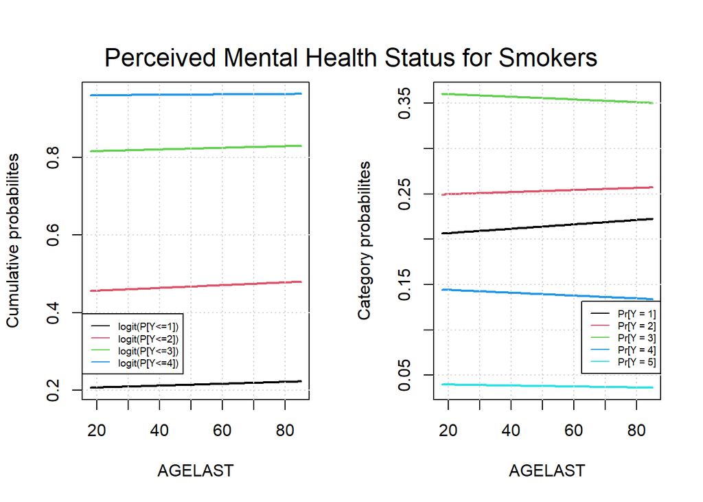

```r
# For smokers
fit <- vglm(MNHLTH31 ~ AGELAST,
             family = cumulative(parallel = TRUE),
             data = smk_df)

df_pred = data.frame(AGELAST = seq(min(smk_df$AGELAST), max(smk_df$AGELAST), by = 1))
preds = predict(fit, df_pred)
cum_probabilities = t(apply(preds,1,plogis))

par(mfrow = c(1,2))
matplot(df_pred$AGELAST,cum_probabilities, lty = 1, type = "l", lwd = 2,
        ylab = "Cumulative probabilites", xlab = "AGELAST")
grid()
legend("bottomleft",
       legend = gsub("link", "", colnames(cum_probabilities)), # remove link from labels
       col = c(1,2,3,4,5), lty = 1, cex = 0.6, xpd = TRUE,
       inset = c(0, 0.08))
category_probabilities = t(apply(cbind(0,cum_probabilities,1),1,diff))
preds = predict(fit, df_pred, type = "response") # check that they are equivalent
matplot(df_pred$AGELAST, preds, lty = 1, type = "l", lwd = 2,
        ylab = "Category probabilites", xlab = "AGELAST")
grid()
legend("topright",
       legend = sprintf("Pr[Y = %g]", 1:5),
       col = c(1,2,3,4,5), lty = 1, cex = 0.6, xpd = TRUE,
       inset = c(0, 0.69))
mtext("Perceived Mental Health Status for Smokers", outer = TRUE, cex = 1.5, line = -3.5)
```

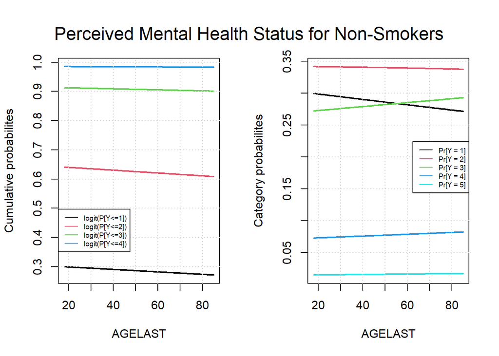

```r
# For non smokers
fit <- vglm(MNHLTH31 ~ AGELAST,
             family = cumulative(parallel = TRUE),
             data = n_smk_df)

df_pred = data.frame(AGELAST = seq(min(n_smk_df$AGELAST), max(n_smk_df$AGELAST), by = 1))
preds = predict(fit, df_pred) # check that they sum to 1
cum_probabilities = t(apply(preds,1,plogis))

par(mfrow = c(1,2))
matplot(df_pred$AGELAST,cum_probabilities, lty = 1, type = "l", lwd = 2,
        ylab = "Cumulative probabilites", xlab = "AGELAST")
grid()
legend("bottomleft",
       legend = gsub("link", "", colnames(cum_probabilities)), # remove link from labels
       col = c(1,2,3,4,5), lty = 1, cex = 0.6, xpd = TRUE,
       inset = c(0, 0.14))
category_probabilities = t(apply(cbind(0,cum_probabilities,1),1,diff))
preds = predict(fit, df_pred, type = "response") # check that they are equivalent
matplot(df_pred$AGELAST, preds, lty = 1, type = "l", lwd = 2,
        ylab = "Category probabilites", xlab = "AGELAST")
grid()
legend("topright",
       legend = sprintf("Pr[Y = %g]", 1:5),
       col = c(1,2,3,4,5), lty = 1, cex = 0.6, xpd = TRUE,
       inset = c(0, 0.37))
mtext("Perceived Mental Health Status for Non-Smokers", outer = TRUE, cex = 1.5, line = -3)
```

From this 2 groups of plots we see that non-smokers tend to have better Perceived Mental Health. The majority of the non-smoking population perceives their mental health as “very good,” with the best category (“excellent,” shown in black) being the second most prevalent up to age 56. In contrast, among smokers, the most common perception is “good,” followed by “very good.” “Excellent” ranks only third.

## 2.3 General Health Smoking

Here, we have performed the same analysis for the “General Health” variable.

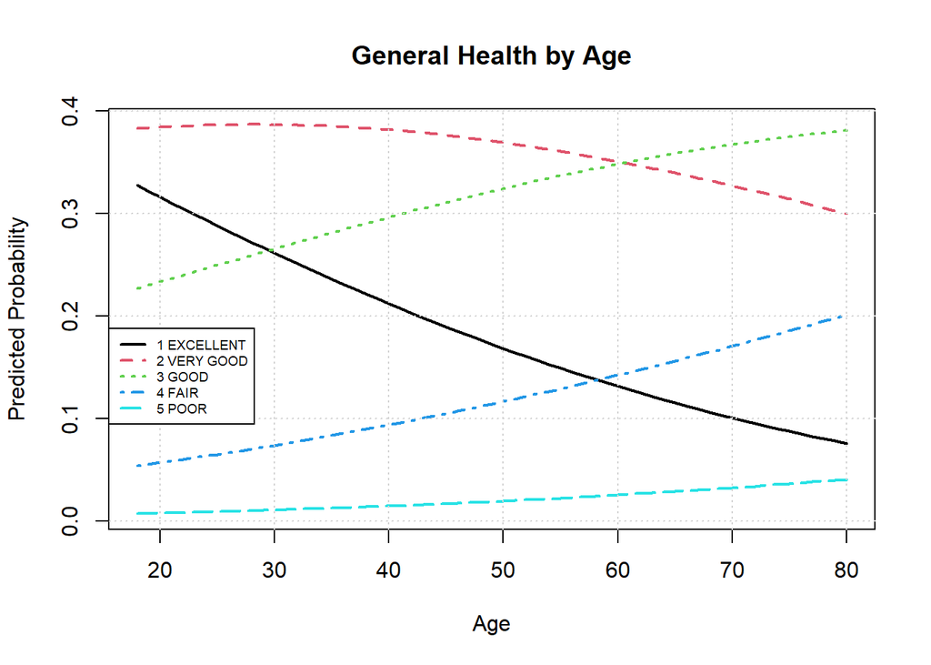

```r
filter_df <-small_df %>% select(ADGENH42, ADSMOK42, SEX, AGELAST, AGEGROUP) %>% filter(rowSums(sapply(., function(x) x %in% values_to_remove)) == 0)

# filter_df <- filter_df %>% filter(AGEGROUP == "65+")

filter_df$ADGENH42 <- relevel(filter_df$ADGENH42, ref = "1 EXCELLENT")
filter_df$ADSMOK42 <- relevel(filter_df$ADSMOK42, ref = "2 NO")
filter_df$SEX <- relevel(filter_df$SEX, ref = "1 MALE")

fit <- vglm(ADGENH42 ~ AGELAST , data = filter_df, family = multinomial)

# summary(fit)

df_pred <- expand.grid(SEX = c("1 MALE", "2 FEMALE"), ADSMOK42 = c("1 YES", "2 NO"), AGELAST = seq(18, 80))


matplot(df_pred$AGELAST, predict(fit, df_pred,type = "response"), type = "l",
        ylab = "Predicted Probability", xlab = "Age", lwd = 2)
title("General Health by Age")
grid()
legend("bottomleft",legend = sort(unique(filter_df$ADGENH42)), col = 1:5, lty = 1:5, lwd = 2, cex = 0.6, inset = c(0, 0.25))
```

The General Health plot is quite different from the previous one, as we see that the effect of age is stronger. In this case we see a strong decreasing in the best cases (Very good and Excellent) and the increase of the others.

```r
confint(fit)
```

```
##                     2.5 %        97.5 %
## (Intercept):1  4.26357682  5.1100094402
## (Intercept):2  4.07383515  4.9055471321
## (Intercept):3  3.32900825  4.1641201093
## (Intercept):4  1.64751697  2.5242616426
## AGELAST:1     -0.05768480 -0.0441035318
## AGELAST:2     -0.03782884 -0.0247116562
## AGELAST:3     -0.02556620 -0.0124293833
## AGELAST:4     -0.01309841  0.0006783151
```

```r
null = vglm(ADGENH42 ~ 1, family = multinomial, data  = filter_df)

print(pseudo_R2 <- 1 - deviance(fit) / deviance(null))
```

```
## [1] 0.02186083
```

```r
anova(fit, test="LRT")
```

```
## Analysis of Deviance Table (Type II tests)
##
## Model: 'multinomial', 'VGAMcategorical'
##
## Link: 'multilogitlink'
##
## Response: ADGENH42
##
##         Df Deviance Resid. Df Resid. Dev  Pr(>Chi)
## AGELAST  4    904.6     59756      41380 < 2.2e-16 ***
## ---
## Signif. codes:  0 '***' 0.001 '**' 0.01 '*' 0.05 '.' 0.1 ' ' 1
```

Than we added the sex variable also in this case and we did some plots

```r
filter_df$ADGENH42 = ordered(filter_df$ADGENH42)
fit <- vglm(ADGENH42 ~ ADSMOK42 + SEX + AGELAST,
             family = cumulative(parallel = TRUE),
             data = filter_df)
summary(fit)
```

```
##
## Call:
## vglm(formula = ADGENH42 ~ ADSMOK42 + SEX + AGELAST, family = cumulative(parallel = TRUE),
##     data = filter_df)
##
## Coefficients:
##                 Estimate Std. Error z value Pr(>|z|)
## (Intercept):1 -0.1321573  0.0504790  -2.618  0.00884 **
## (Intercept):2  1.6604184  0.0519717  31.949  < 2e-16 ***
## (Intercept):3  3.3748393  0.0573363  58.860  < 2e-16 ***
## (Intercept):4  5.4332679  0.0762192  71.285  < 2e-16 ***
## ADSMOK421 YES -0.7088684  0.0389372 -18.205  < 2e-16 ***
## SEX2 FEMALE   -0.1800449  0.0300423  -5.993 2.06e-09 ***
## AGELAST       -0.0252239  0.0008396 -30.043  < 2e-16 ***
## ---
## Signif. codes:  0 '***' 0.001 '**' 0.01 '*' 0.05 '.' 0.1 ' ' 1
##
## Names of linear predictors: logitlink(P[Y<=1]), logitlink(P[Y<=2]),
## logitlink(P[Y<=3]), logitlink(P[Y<=4])
##
## Residual deviance: 40151.52 on 59753 degrees of freedom
##
## Log-likelihood: -20075.76 on 59753 degrees of freedom
##
## Number of Fisher scoring iterations: 4
##
## Warning: Hauck-Donner effect detected in the following estimate(s):
## '(Intercept):4'
##
##
## Exponentiated coefficients:
## ADSMOK421 YES   SEX2 FEMALE       AGELAST
##     0.4922008     0.8352327     0.9750915
```

```r
data <- filter_df
formula <- ADGENH42 ~ ADSMOK42 + SEX + AGELAST

fit_model <- function(data, indices) {
  boot_data <- data[indices, ]
  model <- vglm(formula,
             family = cumulative(parallel = TRUE),
             data = boot_data)
  return(coef(model))
}

set.seed(123)
bootstrap_results <- boot(data = data, statistic = fit_model, R = 100)

bootstrap_results
```

```
##
## ORDINARY NONPARAMETRIC BOOTSTRAP
##
##
## Call:
## boot(data = data, statistic = fit_model, R = 100)
##
##
## Bootstrap Statistics :
##        original        bias     std. error
## t1* -0.13215726 -4.730256e-03 0.0561873669
## t2*  1.66041835 -2.431014e-04 0.0568043897
## t3*  3.37483932  1.344731e-03 0.0617590369
## t4*  5.43326790 -1.390854e-03 0.0801421083
## t5* -0.70886842  5.612468e-03 0.0420773001
## t6* -0.18004489  2.424876e-04 0.0292357120
## t7* -0.02522394 -3.782614e-05 0.0009120621
```

```r
boot.ci(bootstrap_results, type = "basic")
```

```
## BOOTSTRAP CONFIDENCE INTERVAL CALCULATIONS
## Based on 100 bootstrap replicates
##
## CALL :
## boot.ci(boot.out = bootstrap_results, type = "basic")
##
## Intervals :
## Level      Basic
## 95%   (-0.2509, -0.0156 )
## Calculations and Intervals on Original Scale
## Some basic intervals may be unstable
```

Also in this case we checked if our model was robust before splitting in smokers and non-smokers, and it was.

```r
smk_df = filter_df %>% filter(ADSMOK42 == "1 YES")
n_smk_df = filter_df %>% filter(ADSMOK42 == "2 NO")
```

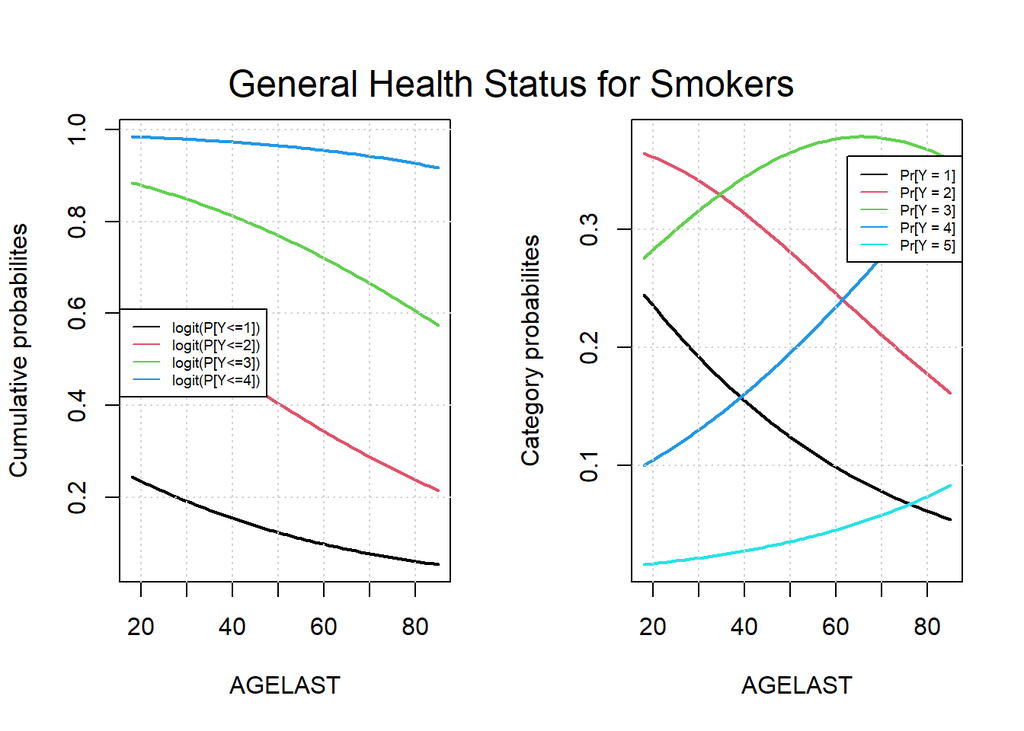

```r
# For smokers
fit <- vglm(ADGENH42 ~ AGELAST,
             family = cumulative(parallel = TRUE),
             data = smk_df)

df_pred = data.frame(AGELAST = seq(min(smk_df$AGELAST), max(smk_df$AGELAST), by = 1))
preds = predict(fit, df_pred)
cum_probabilities = t(apply(preds,1,plogis))

par(mfrow = c(1,2))
matplot(df_pred$AGELAST,cum_probabilities, lty = 1, type = "l", lwd = 2,
        ylab = "Cumulative probabilites", xlab = "AGELAST")
  grid()
legend("bottomleft",
       legend = gsub("link", "", colnames(cum_probabilities)), # remove link from labels
       col = c(1,2,3,4,5), lty = 1, cex = 0.6, xpd = TRUE,
       inset = c(0, 0.4))
category_probabilities = t(apply(cbind(0,cum_probabilities,1),1,diff))
preds = predict(fit, df_pred, type = "response") # check that they are equivalent
matplot(df_pred$AGELAST, preds, lty = 1, type = "l", lwd = 2,
        ylab = "Category probabilites", xlab = "AGELAST")
  grid()
legend("topright",
       legend = sprintf("Pr[Y = %g]", 1:5),
       col = c(1,2,3,4,5), lty = 1, cex = 0.6, xpd = TRUE,
       inset = c(0, 0.08))
mtext("General Health Status for Smokers", outer = TRUE, cex = 1.5, line = -3.5)
```

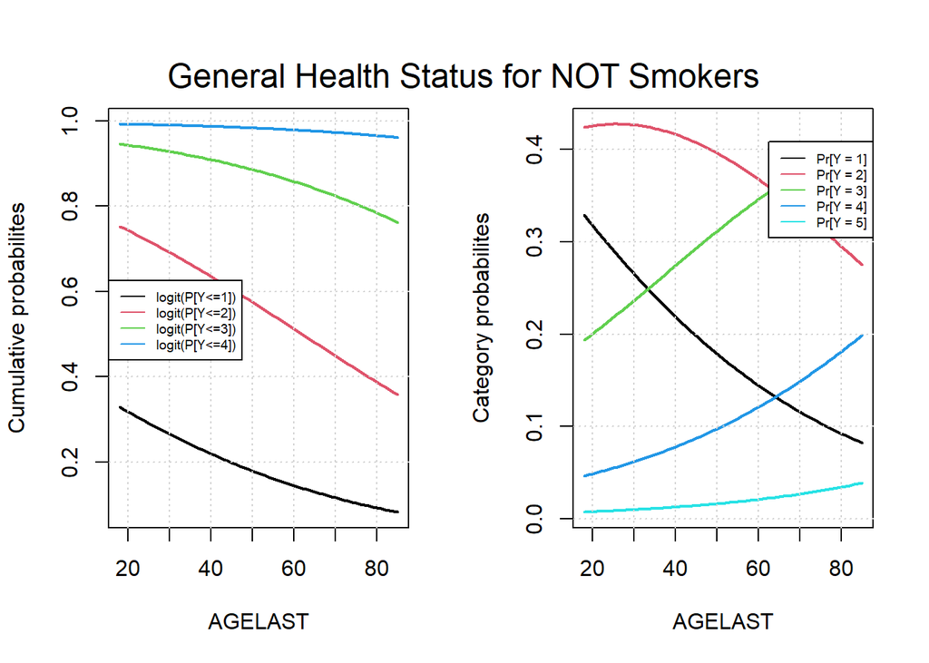

```r
# For not smokers
fit <- vglm(ADGENH42 ~ AGELAST,
             family = cumulative(parallel = TRUE),
             data = n_smk_df)

df_pred = data.frame(AGELAST = seq(min(smk_df$AGELAST), max(smk_df$AGELAST), by = 1))
preds = predict(fit, df_pred)
cum_probabilities = t(apply(preds,1,plogis))

par(mfrow = c(1,2))
matplot(df_pred$AGELAST,cum_probabilities, lty = 1, type = "l", lwd = 2,
        ylab = "Cumulative probabilites", xlab = "AGELAST")
  grid()
legend("bottomleft",
       legend = gsub("link", "", colnames(cum_probabilities)), # remove link from labels
       col = c(1,2,3,4,5), lty = 1, cex = 0.6, xpd = TRUE,
       inset = c(0, 0.4))
category_probabilities = t(apply(cbind(0,cum_probabilities,1),1,diff))
preds = predict(fit, df_pred, type = "response") # check that they are equivalent
matplot(df_pred$AGELAST, preds, lty = 1, type = "l", lwd = 2,
        ylab = "Category probabilites", xlab = "AGELAST")
  grid()
legend("topright",
       legend = sprintf("Pr[Y = %g]", 1:5),
       col = c(1,2,3,4,5), lty = 1, cex = 0.6, xpd = TRUE,
       inset = c(0, 0.08))
mtext("General Health Status for NOT Smokers", outer = TRUE, cex = 1.5, line = -3.5)
```

Also in this case we see that non-smokers tend to have better General Health. Non smokers are starting from higher General Health categories, and are inverting with worst ones later in the years respect to smokers. We can observe that as years pass, the most of the smoker are distributing between the “Good” and “Fair” categories, with also the “Poor” one surpassing the “Excellent” one. For non smokers this inversion never happens, and later in the years, the most of the people are still distributing between the “Very Good” and “Good” categories.

# 3 E-Smoking

Form now on we will repeat the same steps for the E-smoking

## 3.1 Logistic regression for physical health

```r
values_to_remove <- c("-15 CANNOT BE COMPUTED", "-8 DK", "-7 REFUSED", "-1 INAPPLICABLE")
```

### 3.1.1 Stroke

```r
filter_df <- small_df %>% select(STRKDX , SDENICPROD, SEX, AGELAST, AGEGROUP) %>% filter(rowSums(sapply(., function(x) x %in% values_to_remove)) == 0)

# filter_df <- filter_df %>% filter(AGEGROUP == "65+")

filter_df$STRKDX  <- relevel(filter_df$STRKDX , ref = "2 NO")
filter_df$SDENICPROD <- relevel(filter_df$SDENICPROD, ref = "2 NO")
filter_df$SEX <- relevel(filter_df$SEX, ref = "1 MALE")

fit <- glm(STRKDX  ~ SDENICPROD * SEX + AGELAST, data = filter_df, family = "binomial")

summary(fit)
```

```
##
## Call:
## glm(formula = STRKDX ~ SDENICPROD * SEX + AGELAST, family = "binomial",
##     data = filter_df)
##
## Coefficients:
##                              Estimate Std. Error z value Pr(>|z|)
## (Intercept)                 -6.500144   0.177679 -36.584   <2e-16 ***
## SDENICPROD1 YES              0.223148   0.169500   1.317   0.1880
## SEX2 FEMALE                 -0.179755   0.071998  -2.497   0.0125 *
## AGELAST                      0.060259   0.002499  24.118   <2e-16 ***
## SDENICPROD1 YES:SEX2 FEMALE  0.349832   0.226808   1.542   0.1230
## ---
## Signif. codes:  0 '***' 0.001 '**' 0.01 '*' 0.05 '.' 0.1 ' ' 1
##
## (Dispersion parameter for binomial family taken to be 1)
##
##     Null deviance: 7480.7  on 18179  degrees of freedom
## Residual deviance: 6708.6  on 18175  degrees of freedom
## AIC: 6718.6
##
## Number of Fisher Scoring iterations: 6
```

```r
data_point <- filter_df %>%  group_by(AGEGROUP,AGELAST, SEX, SDENICPROD) %>% summarise(WithStroke = sum(STRKDX  == "1 YES"), tot = n()) %>%
  mutate(frequency = WithStroke/tot)
```

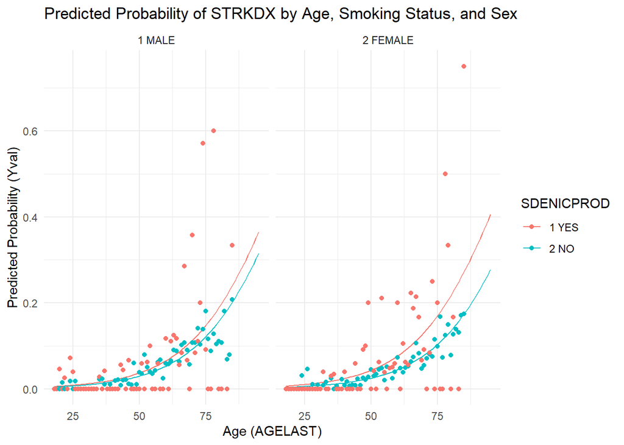

```r
# Creating the prediction data frame
prediction <- expand.grid(SEX = c("1 MALE", "2 FEMALE"), SDENICPROD = c("1 YES", "2 NO"), AGELAST = seq(18, 95))

# Predicting values using the model
prediction$Yval <- predict(fit, newdata = prediction, type = "response")


# Plotting the results
ggplot(prediction, aes(x = AGELAST, y = Yval, col = SDENICPROD)) +
  geom_line() +
  geom_point(data = data_point, aes(y = frequency)) +
  facet_wrap(~SEX) +
  labs(title = "Predicted Probability of STRKDX by Age, Smoking Status, and Sex",
       x = "Age (AGELAST)",
       y = "Predicted Probability (Yval)") +
  theme_minimal()
```

### 3.1.2 Asthma

```r
filter_df <- small_df %>% select(ASTHDX, SDENICPROD, SEX, AGELAST, AGEGROUP) %>% filter(rowSums(sapply(., function(x) x %in% values_to_remove)) == 0)

# filter_df <- filter_df %>% filter(AGEGROUP == c("18-24"))

filter_df$ASTHDX <- relevel(filter_df$ASTHDX, ref = "2 NO")
filter_df$SDENICPROD <- relevel(filter_df$SDENICPROD, ref = "2 NO")
filter_df$SEX <- relevel(filter_df$SEX, ref = "1 MALE")


fit <- glm(ASTHDX ~ SDENICPROD * SEX + AGELAST, data = filter_df, family = "binomial")

summary(fit)
```

```
##
## Call:
## glm(formula = ASTHDX ~ SDENICPROD * SEX + AGELAST, family = "binomial",
##     data = filter_df)
##
## Coefficients:
##                              Estimate Std. Error z value Pr(>|z|)
## (Intercept)                 -1.795164   0.072533 -24.750  < 2e-16 ***
## SDENICPROD1 YES              0.309304   0.086392   3.580 0.000343 ***
## SEX2 FEMALE                  0.317237   0.046701   6.793  1.1e-11 ***
## AGELAST                     -0.003152   0.001169  -2.697 0.006999 **
## SDENICPROD1 YES:SEX2 FEMALE  0.138970   0.112743   1.233 0.217715
## ---
## Signif. codes:  0 '***' 0.001 '**' 0.01 '*' 0.05 '.' 0.1 ' ' 1
##
## (Dispersion parameter for binomial family taken to be 1)
##
##     Null deviance: 15498  on 18180  degrees of freedom
## Residual deviance: 15375  on 18176  degrees of freedom
## AIC: 15385
##
## Number of Fisher Scoring iterations: 4
```

```r
data_point <- filter_df %>%  group_by(AGEGROUP,AGELAST, SEX, SDENICPROD) %>% summarise(WithAsthma = sum(ASTHDX == "1 YES"), tot = n()) %>%
  mutate(frequency = WithAsthma/tot)
```

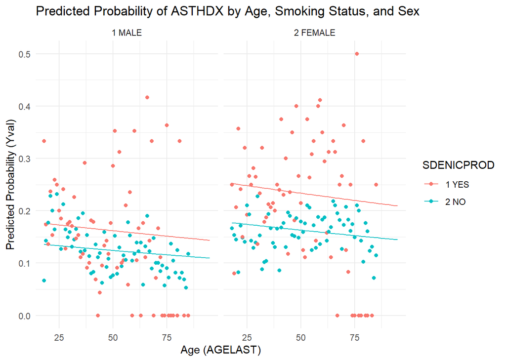

```r
prediction <- expand.grid(SEX = c("1 MALE", "2 FEMALE"), SDENICPROD = c("1 YES", "2 NO"), AGELAST = seq(18, 95))

# Predicting values using the model
prediction$Yval <- predict(fit, newdata = prediction, type = "response")


# Plotting the results
ggplot(prediction, aes(x = AGELAST, y = Yval, col = SDENICPROD)) +
  geom_line() +
  geom_point(data = data_point, aes(y = frequency)) +
  facet_wrap(~SEX) +
  labs(title = "Predicted Probability of ASTHDX by Age, Smoking Status, and Sex",
       x = "Age (AGELAST)",
       y = "Predicted Probability (Yval)") +
  theme_minimal()
```

### 3.1.3 Arthritis

```r
filter_df <- small_df %>% select(ARTHDX , SDENICPROD, SEX, AGELAST, AGEGROUP) %>% filter(rowSums(sapply(., function(x) x %in% values_to_remove)) == 0)

# filter_df <- filter_df %>% filter(AGEGROUP == c("18-24"))

filter_df$ARTHDX  <- relevel(filter_df$ARTHDX , ref = "2 NO")
filter_df$SDENICPROD <- relevel(filter_df$SDENICPROD, ref = "2 NO")
filter_df$SEX <- relevel(filter_df$SEX, ref = "1 MALE")


fit <- glm(ARTHDX  ~ SDENICPROD * SEX + AGELAST, data = filter_df, family = "binomial")

summary(fit)
```

```
##
## Call:
## glm(formula = ARTHDX ~ SDENICPROD * SEX + AGELAST, family = "binomial",
##     data = filter_df)
##
## Coefficients:
##                             Estimate Std. Error z value Pr(>|z|)
## (Intercept)                 -5.37596    0.08785 -61.194  < 2e-16 ***
## SDENICPROD1 YES              0.44257    0.08876   4.986 6.16e-07 ***
## SEX2 FEMALE                  0.61273    0.03999  15.323  < 2e-16 ***
## AGELAST                      0.07392    0.00130  56.841  < 2e-16 ***
## SDENICPROD1 YES:SEX2 FEMALE  0.16719    0.11586   1.443    0.149
## ---
## Signif. codes:  0 '***' 0.001 '**' 0.01 '*' 0.05 '.' 0.1 ' ' 1
##
## (Dispersion parameter for binomial family taken to be 1)
##
##     Null deviance: 22791  on 18178  degrees of freedom
## Residual deviance: 17880  on 18174  degrees of freedom
## AIC: 17890
##
## Number of Fisher Scoring iterations: 5
```

```r
data_point <- filter_df %>%  group_by(AGEGROUP,AGELAST, SEX, SDENICPROD) %>% summarise(WithAsthma = sum(ARTHDX  == "1 YES"), tot = n()) %>%
  mutate(frequency = WithAsthma/tot)
```

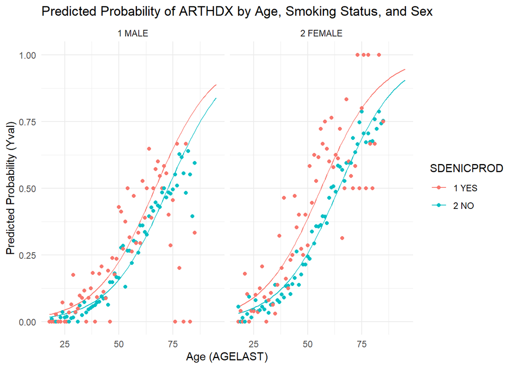

```r
prediction <- expand.grid(SEX = c("1 MALE", "2 FEMALE"), SDENICPROD = c("1 YES", "2 NO"), AGELAST = seq(18, 95))

# Predicting values using the model
prediction$Yval <- predict(fit, newdata = prediction, type = "response")


# Plotting the results
ggplot(prediction, aes(x = AGELAST, y = Yval, col = SDENICPROD)) +
  geom_line() +
  geom_point(data = data_point, aes(y = frequency)) +
  facet_wrap(~SEX) +
  labs(title = "Predicted Probability of ARTHDX by Age, Smoking Status, and Sex",
       x = "Age (AGELAST)",
       y = "Predicted Probability (Yval)") +
  theme_minimal()
```

### 3.1.4 High Cholesterol

```r
filter_df <- small_df %>% select(CHOLDX, SDENICPROD, SEX, AGELAST, AGEGROUP) %>% filter(rowSums(sapply(., function(x) x %in% values_to_remove)) == 0)

# filter_df <- filter_df %>% filter(AGEGROUP == "65+")

filter_df$CHOLDX <- relevel(filter_df$CHOLDX, ref = "2 NO")
filter_df$SDENICPROD <- relevel(filter_df$SDENICPROD, ref = "2 NO")
filter_df$SEX <- relevel(filter_df$SEX, ref = "1 MALE")


fit <- glm(CHOLDX ~ SDENICPROD * SEX + AGELAST, data = filter_df, family = "binomial")

summary(fit)
```

```
##
## Call:
## glm(formula = CHOLDX ~ SDENICPROD * SEX + AGELAST, family = "binomial",
##     data = filter_df)
##
## Coefficients:
##                             Estimate Std. Error z value Pr(>|z|)
## (Intercept)                 -3.80149    0.07078 -53.707  < 2e-16 ***
## SDENICPROD1 YES              0.15384    0.07640   2.014   0.0441 *
## SEX2 FEMALE                 -0.15438    0.03677  -4.199 2.69e-05 ***
## AGELAST                      0.06046    0.00112  54.002  < 2e-16 ***
## SDENICPROD1 YES:SEX2 FEMALE  0.12071    0.10611   1.138   0.2553
## ---
## Signif. codes:  0 '***' 0.001 '**' 0.01 '*' 0.05 '.' 0.1 ' ' 1
##
## (Dispersion parameter for binomial family taken to be 1)
##
##     Null deviance: 24025  on 18166  degrees of freedom
## Residual deviance: 20158  on 18162  degrees of freedom
## AIC: 20168
##
## Number of Fisher Scoring iterations: 4
```

```r
data_point <- filter_df %>%  group_by(AGELAST, SEX, SDENICPROD) %>% summarise(WithChol = sum(CHOLDX == "1 YES"), tot = n()) %>%
  mutate(frequency = WithChol/tot)
```

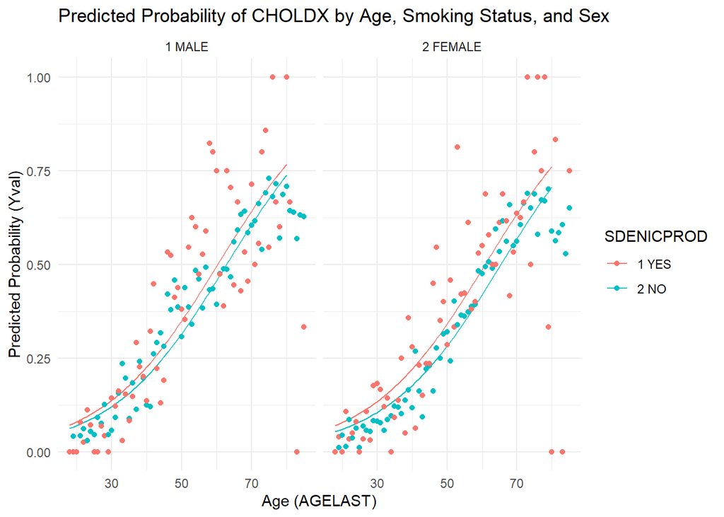

```r
prediction <- expand.grid(SEX = c("1 MALE", "2 FEMALE"), SDENICPROD = c("1 YES", "2 NO"), AGELAST = seq(18, 80))


prediction$Yval <- predict(fit, newdata = prediction, type = "response")

ggplot(prediction, aes(x = AGELAST, y = Yval, col = SDENICPROD)) +
  geom_line() +
  geom_point(data = data_point, aes(y = frequency)) +
  facet_wrap(~SEX) +
  labs(title = "Predicted Probability of CHOLDX by Age, Smoking Status, and Sex",
       x = "Age (AGELAST)",
       y = "Predicted Probability (Yval)") +
  theme_minimal()
```

### 3.1.5 Diabetes

```r
filter_df <- small_df %>% select(DIABDX_M18 , SDENICPROD, SEX, AGELAST, AGEGROUP) %>% filter(rowSums(sapply(., function(x) x %in% values_to_remove)) == 0)


# filter_df <- filter_df %>% filter(AGEGROUP == "65+")

filter_df$DIABDX_M18 <- relevel(filter_df$DIABDX_M18 , ref = "2 NO")
filter_df$SDENICPROD <- relevel(filter_df$SDENICPROD, ref = "2 NO")
filter_df$SEX <- relevel(filter_df$SEX, ref = "1 MALE")


fit <- glm(DIABDX_M18 ~ SDENICPROD * SEX + AGELAST, data = filter_df, family = "binomial")

summary(fit)
```

```
##
## Call:
## glm(formula = DIABDX_M18 ~ SDENICPROD * SEX + AGELAST, family = "binomial",
##     data = filter_df)
##
## Coefficients:
##                              Estimate Std. Error z value Pr(>|z|)
## (Intercept)                 -4.252017   0.094413 -45.036   <2e-16 ***
## SDENICPROD1 YES             -0.002929   0.105803  -0.028    0.978
## SEX2 FEMALE                 -0.084187   0.045799  -1.838    0.066 .
## AGELAST                      0.044011   0.001399  31.462   <2e-16 ***
## SDENICPROD1 YES:SEX2 FEMALE  0.082964   0.146543   0.566    0.571
## ---
## Signif. codes:  0 '***' 0.001 '**' 0.01 '*' 0.05 '.' 0.1 ' ' 1
##
## (Dispersion parameter for binomial family taken to be 1)
##
##     Null deviance: 15230  on 18178  degrees of freedom
## Residual deviance: 14010  on 18174  degrees of freedom
## AIC: 14020
##
## Number of Fisher Scoring iterations: 5
```

```r
data_point <- filter_df %>%  group_by(AGELAST, SEX, SDENICPROD) %>% summarise(WithBronch = sum(DIABDX_M18 == "1 YES"), tot = n()) %>%
  mutate(frequency = WithBronch/tot)
```

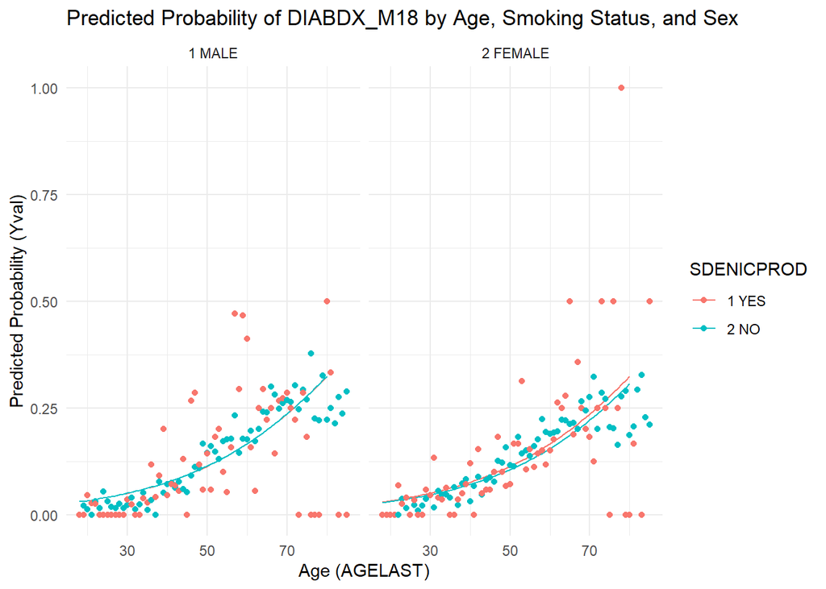

```r
# Creating the prediction data frame
df_pred <- expand.grid(SEX = c("1 MALE", "2 FEMALE"), SDENICPROD = c("1 YES", "2 NO"), AGELAST = seq(18, 80))

# Predicting values using the model
df_pred$Yval <- predict(fit, newdata = df_pred, type = "response")


# Plotting the results
ggplot(df_pred, aes(x = AGELAST, y = Yval, col = SDENICPROD)) +
  geom_line() +
  geom_point(data = data_point, aes(y = frequency)) +
  facet_wrap(~SEX) +
  labs(title = "Predicted Probability of DIABDX_M18 by Age, Smoking Status, and Sex",
       x = "Age (AGELAST)",
       y = "Predicted Probability (Yval)") +
  theme_minimal()
```

### 3.1.6 High Blood Pressure

```r
filter_df <- small_df %>% select(HIBPDX, SDENICPROD, SEX, AGELAST, AGEGROUP) %>% filter(rowSums(sapply(., function(x) x %in% values_to_remove)) == 0)

# filter_df <- filter_df %>% filter(AGEGROUP == "65+")

filter_df$HIBPDX <- relevel(filter_df$HIBPDX, ref = "2 NO")
filter_df$SDENICPROD <- relevel(filter_df$SDENICPROD, ref = "2 NO")
filter_df$SEX <- relevel(filter_df$SEX, ref = "1 MALE")


fit <- glm(HIBPDX ~ SDENICPROD * SEX + AGELAST, data = filter_df, family = "binomial")

summary(fit)
```

```
##
## Call:
## glm(formula = HIBPDX ~ SDENICPROD * SEX + AGELAST, family = "binomial",
##     data = filter_df)
##
## Coefficients:
##                              Estimate Std. Error z value Pr(>|z|)
## (Intercept)                 -4.023559   0.072194 -55.733  < 2e-16 ***
## SDENICPROD1 YES              0.410370   0.075027   5.470 4.51e-08 ***
## SEX2 FEMALE                 -0.177501   0.037231  -4.768 1.86e-06 ***
## AGELAST                      0.066655   0.001154  57.764  < 2e-16 ***
## SDENICPROD1 YES:SEX2 FEMALE -0.178396   0.105726  -1.687   0.0915 .
## ---
## Signif. codes:  0 '***' 0.001 '**' 0.01 '*' 0.05 '.' 0.1 ' ' 1
##
## (Dispersion parameter for binomial family taken to be 1)
##
##     Null deviance: 24447  on 18171  degrees of freedom
## Residual deviance: 19861  on 18167  degrees of freedom
## AIC: 19871
##
## Number of Fisher Scoring iterations: 4
```

```r
data_point <- filter_df %>%  group_by(AGELAST, SEX, SDENICPROD) %>% summarise(WithPress = sum(HIBPDX == "1 YES"), tot = n()) %>%
  mutate(frequency = WithPress/tot)
```

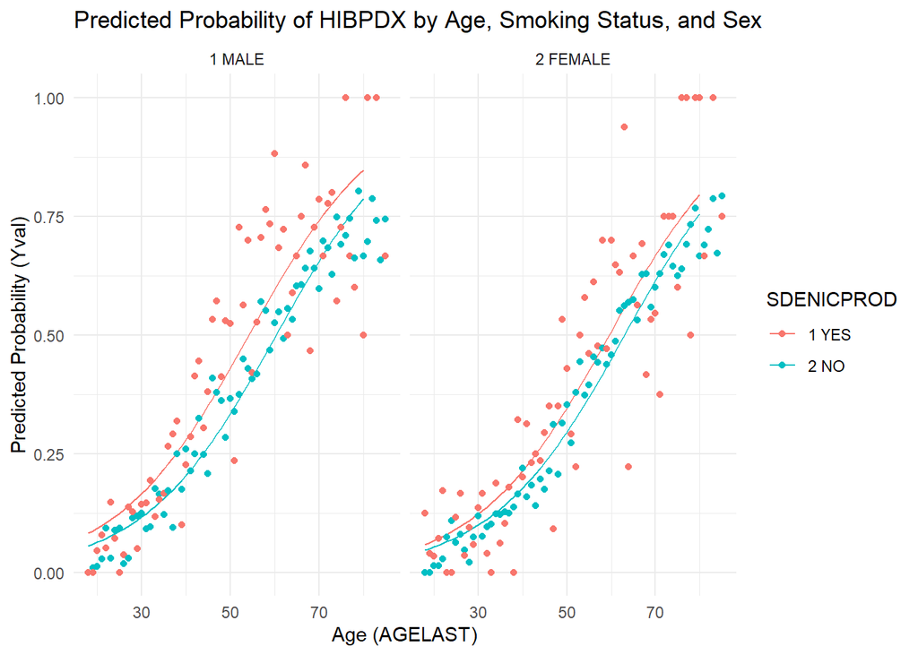

```r
# Creating the prediction data frame
df_pred <- expand.grid(SEX = c("1 MALE", "2 FEMALE"), SDENICPROD = c("1 YES", "2 NO"), AGELAST = seq(18, 80))

# Predicting values using the model
df_pred$Yval <- predict(fit, newdata = df_pred, type = "response")


# Plotting the results
ggplot(df_pred, aes(x = AGELAST, y = Yval, col = SDENICPROD)) +
  geom_line() +
  geom_point(data = data_point, aes(y = frequency)) +
  facet_wrap(~SEX) +
  labs(title = "Predicted Probability of HIBPDX by Age, Smoking Status, and Sex",
       x = "Age (AGELAST)",
       y = "Predicted Probability (Yval)") +
  theme_minimal()
```

### 3.1.7 Lung cancer

```r
filter_df <- small_df %>% select(CALUNG, SDENICPROD, SEX, AGELAST, AGEGROUP) %>% filter(rowSums(sapply(., function(x) x %in% values_to_remove)) == 0)

# filter_df <- filter_df %>% filter(AGEGROUP == "65+")

filter_df$CALUNG <- relevel(filter_df$CALUNG, ref = "2 NO")
filter_df$SDENICPROD <- relevel(filter_df$SDENICPROD, ref = "2 NO")
filter_df$SEX <- relevel(filter_df$SEX, ref = "1 MALE")


fit <- glm(CALUNG ~ SDENICPROD * SEX + AGELAST, data = filter_df, family = "binomial")

summary(fit)
```

```
##
## Call:
## glm(formula = CALUNG ~ SDENICPROD * SEX + AGELAST, family = "binomial",
##     data = filter_df)
##
## Coefficients:
##                             Estimate Std. Error z value Pr(>|z|)
## (Intercept)                 -6.12639    0.85751  -7.144 9.04e-13 ***
## SDENICPROD1 YES              1.63074    0.45677   3.570 0.000357 ***
## SEX2 FEMALE                  0.07510    0.26186   0.287 0.774257
## AGELAST                      0.03470    0.01124   3.087 0.002019 **
## SDENICPROD1 YES:SEX2 FEMALE -0.41933    0.61786  -0.679 0.497337
## ---
## Signif. codes:  0 '***' 0.001 '**' 0.01 '*' 0.05 '.' 0.1 ' ' 1
##
## (Dispersion parameter for binomial family taken to be 1)
##
##     Null deviance: 682.92  on 2536  degrees of freedom
## Residual deviance: 661.99  on 2532  degrees of freedom
## AIC: 671.99
##
## Number of Fisher Scoring iterations: 6
```

```r
data_point <- filter_df %>%  group_by(AGELAST, SEX, SDENICPROD) %>% summarise(WithPress = sum(CALUNG == "1 YES"), tot = n()) %>%
  mutate(frequency = WithPress/tot)
```

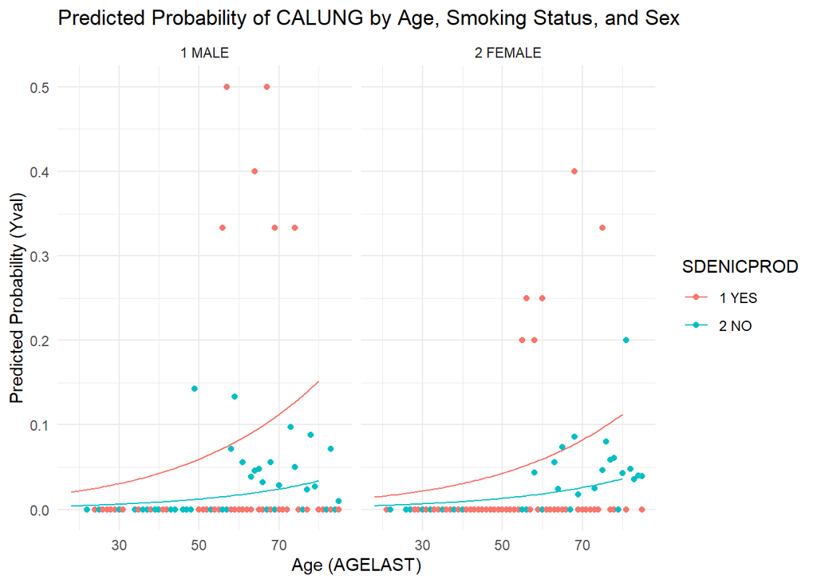

```r
# Creating the prediction data frame
df_pred <- expand.grid(SEX = c("1 MALE", "2 FEMALE"), SDENICPROD = c("1 YES", "2 NO"), AGELAST = seq(18, 80))

# Predicting values using the model
df_pred$Yval <- predict(fit, newdata = df_pred, type = "response")


# Plotting the results
ggplot(df_pred, aes(x = AGELAST, y = Yval, col = SDENICPROD)) +
  geom_line() +
  geom_point(data = data_point, aes(y = frequency)) +
  facet_wrap(~SEX) +
  labs(title = "Predicted Probability of CALUNG by Age, Smoking Status, and Sex",
       x = "Age (AGELAST)",
       y = "Predicted Probability (Yval)") +
  theme_minimal()
```

### 3.1.8 Bronchitis

```r
filter_df <- small_df %>% select(CHBRON31, SDENICPROD, SEX, AGELAST, AGEGROUP) %>% filter(rowSums(sapply(., function(x) x %in% values_to_remove)) == 0)

# filter_df <- filter_df %>% filter(AGEGROUP == "65+")

filter_df$CHBRON31 <- relevel(filter_df$CHBRON31, ref = "2 NO")
filter_df$SDENICPROD <- relevel(filter_df$SDENICPROD, ref = "2 NO")
filter_df$SEX <- relevel(filter_df$SEX, ref = "1 MALE")


fit <- glm(CHBRON31 ~ SDENICPROD * SEX + AGELAST, data = filter_df, family = "binomial")

summary(fit)
```

```
##
## Call:
## glm(formula = CHBRON31 ~ SDENICPROD * SEX + AGELAST, family = "binomial",
##     data = filter_df)
##
## Coefficients:
##                              Estimate Std. Error z value Pr(>|z|)
## (Intercept)                 -5.965273   0.252848 -23.592  < 2e-16 ***
## SDENICPROD1 YES              0.774959   0.259697   2.984 0.002844 **
## SEX2 FEMALE                  0.491805   0.144139   3.412 0.000645 ***
## AGELAST                      0.024422   0.003629   6.729 1.71e-11 ***
## SDENICPROD1 YES:SEX2 FEMALE  0.167296   0.314788   0.531 0.595102
## ---
## Signif. codes:  0 '***' 0.001 '**' 0.01 '*' 0.05 '.' 0.1 ' ' 1
##
## (Dispersion parameter for binomial family taken to be 1)
##
##     Null deviance: 2908.0  on 18138  degrees of freedom
## Residual deviance: 2829.6  on 18134  degrees of freedom
## AIC: 2839.6
##
## Number of Fisher Scoring iterations: 7
```

```r
data_point <- filter_df %>%  group_by(AGELAST, SEX, SDENICPROD) %>% summarise(WithPress = sum(CHBRON31 == "1 YES"), tot = n()) %>%
  mutate(frequency = WithPress/tot)
```

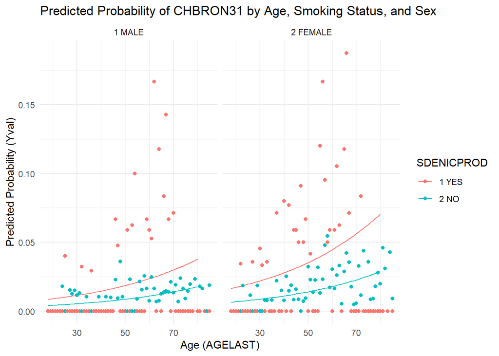

```r
# Creating the prediction data frame
df_pred <- expand.grid(SEX = c("1 MALE", "2 FEMALE"), SDENICPROD = c("1 YES", "2 NO"), AGELAST = seq(18, 80))

# Predicting values using the model
df_pred$Yval <- predict(fit, newdata = df_pred, type = "response")


# Plotting the results
ggplot(df_pred, aes(x = AGELAST, y = Yval, col = SDENICPROD)) +
  geom_line() +
  geom_point(data = data_point, aes(y = frequency)) +
  facet_wrap(~SEX) +
  labs(title = "Predicted Probability of CHBRON31 by Age, Smoking Status, and Sex",
       x = "Age (AGELAST)",
       y = "Predicted Probability (Yval)") +
  theme_minimal()
```

### 3.1.9 Emphysema

```r
filter_df <- small_df %>% select(EMPHDX, SDENICPROD, SEX, AGELAST, AGEGROUP) %>% filter(rowSums(sapply(., function(x) x %in% values_to_remove)) == 0)

# filter_df <- filter_df %>% filter(AGEGROUP == "65+")

filter_df$EMPHDX <- relevel(filter_df$EMPHDX, ref = "2 NO")
filter_df$SDENICPROD <- relevel(filter_df$SDENICPROD, ref = "2 NO")
filter_df$SEX <- relevel(filter_df$SEX, ref = "1 MALE")


fit <- glm(EMPHDX ~ SDENICPROD * SEX + AGELAST, data = filter_df, family = "binomial")

summary(fit)
```

```
##
## Call:
## glm(formula = EMPHDX ~ SDENICPROD * SEX + AGELAST, family = "binomial",
##     data = filter_df)
##
## Coefficients:
##                              Estimate Std. Error z value Pr(>|z|)
## (Intercept)                 -8.212236   0.286992 -28.615  < 2e-16 ***
## SDENICPROD1 YES              1.253981   0.193914   6.467    1e-10 ***
## SEX2 FEMALE                 -0.216396   0.114750  -1.886  0.05932 .
## AGELAST                      0.069836   0.003905  17.883  < 2e-16 ***
## SDENICPROD1 YES:SEX2 FEMALE  0.696956   0.245796   2.836  0.00458 **
## ---
## Signif. codes:  0 '***' 0.001 '**' 0.01 '*' 0.05 '.' 0.1 ' ' 1
##
## (Dispersion parameter for binomial family taken to be 1)
##
##     Null deviance: 3972.7  on 18178  degrees of freedom
## Residual deviance: 3497.9  on 18174  degrees of freedom
## AIC: 3507.9
##
## Number of Fisher Scoring iterations: 7
```

```r
data_point <- filter_df %>%  group_by(AGELAST, SEX, SDENICPROD) %>% summarise(WithPress = sum(EMPHDX == "1 YES"), tot = n()) %>%
  mutate(frequency = WithPress/tot)
```

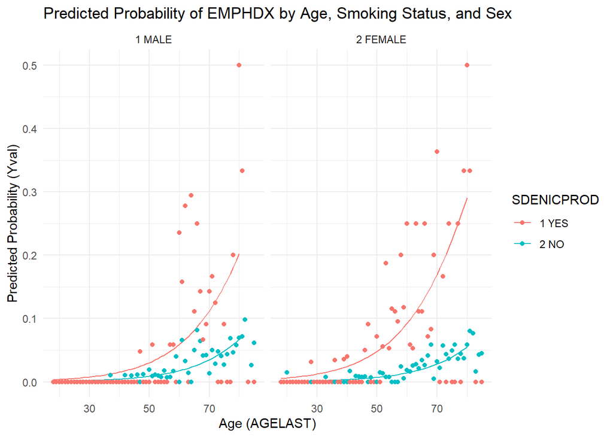

```r
# Creating the prediction data frame
df_pred <- expand.grid(SEX = c("1 MALE", "2 FEMALE"), SDENICPROD = c("1 YES", "2 NO"), AGELAST = seq(18, 80))

# Predicting values using the model
df_pred$Yval <- predict(fit, newdata = df_pred, type = "response")


# Plotting the results
ggplot(df_pred, aes(x = AGELAST, y = Yval, col = SDENICPROD)) +
  geom_line() +
  geom_point(data = data_point, aes(y = frequency)) +
  facet_wrap(~SEX) +
  labs(title = "Predicted Probability of EMPHDX by Age, Smoking Status, and Sex",
       x = "Age (AGELAST)",
       y = "Predicted Probability (Yval)") +
  theme_minimal()
```

To sum up all the results we can see above, even if the results are based on a different section of the population (because as we saw above cigarettes and electronic smoking devices are distributed in different ways), the results are pretty similar. With respect to cigarettes, the difference between smokers and non smokers are more accentuated in some cases, but most times are a little bit less present. That’s because the data in our possession about e-smokers are more distributed around younger ages, in which usually people tends to stay better regardless. Even with this specification, the variable is still very significant in most of our models, signalling that even if you smoke electronic cigarettes, not smoking at all tends to be increase the probabilities of staying better.

## 3.2 Multilogit regression for Mental Health

### 3.2.1 Perceived Mental Health Status

```r
filter_df <-small_df %>% select(MNHLTH31, SDENICPROD, SEX, AGELAST) %>% filter(rowSums(sapply(., function(x) x %in% values_to_remove)) == 0)

# filter_df <- filter_df %>% filter(AGEGROUP == "65+")

filter_df$MNHLTH31 <- relevel(filter_df$MNHLTH31, ref = "1 EXCELLENT")
filter_df$SDENICPROD <- relevel(filter_df$SDENICPROD, ref = "2 NO")
filter_df$SEX <- relevel(filter_df$SEX, ref = "1 MALE")
```

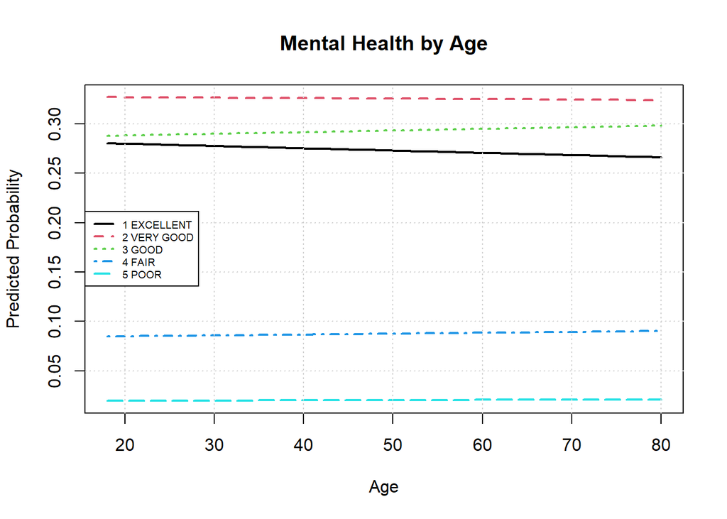

```r
filter_df$MNHLTH31 = ordered(filter_df$MNHLTH31)

df_pred <- expand.grid(SEX = c("1 MALE", "2 FEMALE"), SDENICPROD = c("1 YES", "2 NO"), AGELAST = seq(18, 80))

fit <- vglm(MNHLTH31 ~ AGELAST,
             family = cumulative(parallel = TRUE),
             data = filter_df)

matplot(df_pred$AGELAST, predict(fit, df_pred,type = "response"), type = "l",
        ylab = "Predicted Probability", xlab = "Age", lwd = 2)
title("Mental Health by Age")
grid()
legend("left",legend = sort(unique(filter_df$MNHLTH31)), col = 1:5, lty = 1:5, lwd = 2, cex = 0.6)
```

```r
null <-  vglm(MNHLTH31 ~ 1,
             family = cumulative(parallel = TRUE),
             data = filter_df)

pchisq(deviance(null)-deviance(fit), df <- df.residual(null)-df.residual(fit), lower.tail=FALSE)
```

```
## [1] 0.1164615
```

```r
fit <- vglm(MNHLTH31 ~ SDENICPROD + SEX + AGELAST,
             family = cumulative(parallel = TRUE),
             data = filter_df)
summary(fit)
```

```
##
## Call:
## vglm(formula = MNHLTH31 ~ SDENICPROD + SEX + AGELAST, family = cumulative(parallel = TRUE),
##     data = filter_df)
##
## Coefficients:
##                   Estimate Std. Error z value Pr(>|z|)
## (Intercept):1   -0.5917390  0.0467452 -12.659  < 2e-16 ***
## (Intercept):2    0.8014889  0.0469039  17.088  < 2e-16 ***
## (Intercept):3    2.5282903  0.0510390  49.536  < 2e-16 ***
## (Intercept):4    4.2967733  0.0692881  62.013  < 2e-16 ***
## SDENICPROD1 YES -0.5626211  0.0407733 -13.799  < 2e-16 ***
## SEX2 FEMALE     -0.2710512  0.0270943 -10.004  < 2e-16 ***
## AGELAST         -0.0033686  0.0007562  -4.455  8.4e-06 ***
## ---
## Signif. codes:  0 '***' 0.001 '**' 0.01 '*' 0.05 '.' 0.1 ' ' 1
##
## Names of linear predictors: logitlink(P[Y<=1]), logitlink(P[Y<=2]),
## logitlink(P[Y<=3]), logitlink(P[Y<=4])
##
## Residual deviance: 49614.98 on 72677 degrees of freedom
##
## Log-likelihood: -24807.49 on 72677 degrees of freedom
##
## Number of Fisher scoring iterations: 4
##
## Warning: Hauck-Donner effect detected in the following estimate(s):
## '(Intercept):4'
##
##
## Exponentiated coefficients:
## SDENICPROD1 YES     SEX2 FEMALE         AGELAST
##       0.5697138       0.7625775       0.9966371
```

```r
data <- filter_df
formula <- MNHLTH31  ~ SDENICPROD  + SEX + AGELAST

fit_model <- function(data, indices) {
  boot_data <- data[indices, ]
  model <- vglm(formula,
             family = cumulative(parallel = TRUE),
             data = boot_data)
  return(coef(model))
}

set.seed(123)
bootstrap_results <- boot(data = data, statistic = fit_model, R = 100)

bootstrap_results
```

```
##
## ORDINARY NONPARAMETRIC BOOTSTRAP
##
##
## Call:
## boot(data = data, statistic = fit_model, R = 100)
##
##
## Bootstrap Statistics :
##         original        bias     std. error
## t1* -0.591738980  1.433870e-03 0.0452970293
## t2*  0.801488911 -1.015003e-03 0.0474743409
## t3*  2.528290262 -8.625583e-04 0.0548296667
## t4*  4.296773306  1.272134e-03 0.0706058286
## t5* -0.562621062  5.643856e-03 0.0443905054
## t6* -0.271051163 -2.033241e-03 0.0240889656
## t7* -0.003368567  2.181939e-05 0.0007284386
```

```r
boot.ci(bootstrap_results, type = "basic")
```

```
## BOOTSTRAP CONFIDENCE INTERVAL CALCULATIONS
## Based on 100 bootstrap replicates
##
## CALL :
## boot.ci(boot.out = bootstrap_results, type = "basic")
##
## Intervals :
## Level      Basic
## 95%   (-0.6856, -0.5046 )
## Calculations and Intervals on Original Scale
## Some basic intervals may be unstable
```

#### 3.2.1.1 Difference between smokers and non smokers

```r
smk_df = filter_df %>% filter(SDENICPROD == "1 YES")
n_smk_df = filter_df %>% filter(SDENICPROD == "2 NO")
```

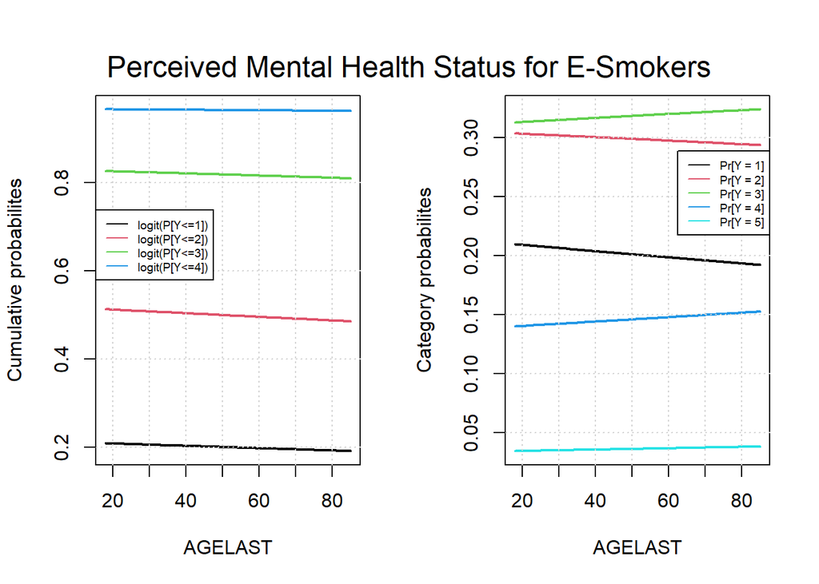

```r
# For smokers
fit <- vglm(MNHLTH31 ~ AGELAST,
             family = cumulative(parallel = TRUE),
             data = smk_df)

df_pred = data.frame(AGELAST = seq(min(smk_df$AGELAST), max(smk_df$AGELAST), by = 1))
preds = predict(fit, df_pred)
cum_probabilities = t(apply(preds,1,plogis))

par(mfrow = c(1,2))
matplot(df_pred$AGELAST,cum_probabilities, lty = 1, type = "l", lwd = 2,
        ylab = "Cumulative probabilites", xlab = "AGELAST")
grid()
legend("bottomleft",
       legend = gsub("link", "", colnames(cum_probabilities)), # remove link from labels
       col = c(1,2,3,4,5), lty = 1, cex = 0.6, xpd = TRUE,
       inset = c(0, 0.5))
category_probabilities = t(apply(cbind(0,cum_probabilities,1),1,diff))
preds = predict(fit, df_pred, type = "response") # check that they are equivalent
matplot(df_pred$AGELAST, preds, lty = 1, type = "l", lwd = 2,
        ylab = "Category probabilites", xlab = "AGELAST")
grid()
legend("topright",
       legend = sprintf("Pr[Y = %g]", 1:5),
       col = c(1,2,3,4,5), lty = 1, cex = 0.6, xpd = TRUE,
       inset = c(0, 0.15))
mtext("Perceived Mental Health Status for E-Smokers", outer = TRUE, cex = 1.5, line = -3.5)
```

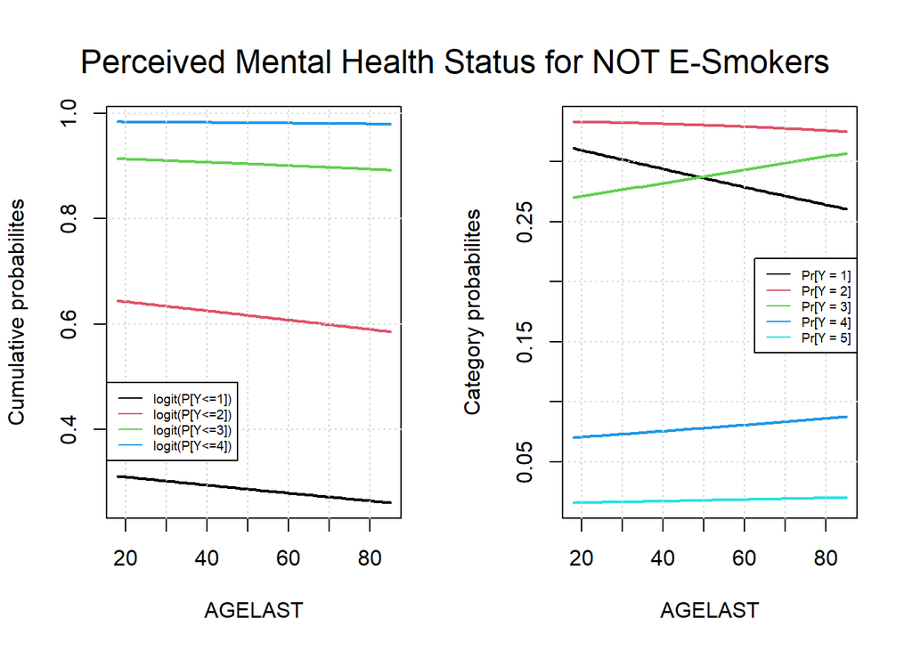

```r
# For non smokers
fit <- vglm(MNHLTH31 ~ AGELAST,
             family = cumulative(parallel = TRUE),
             data = n_smk_df)

df_pred = data.frame(AGELAST = seq(min(n_smk_df$AGELAST), max(n_smk_df$AGELAST), by = 1))
preds = predict(fit, df_pred) # check that they sum to 1
cum_probabilities = t(apply(preds,1,plogis))

par(mfrow = c(1,2))
matplot(df_pred$AGELAST,cum_probabilities, lty = 1, type = "l", lwd = 2,
        ylab = "Cumulative probabilites", xlab = "AGELAST")
grid()
legend("bottomleft",
       legend = gsub("link", "", colnames(cum_probabilities)), # remove link from labels
       col = c(1,2,3,4,5), lty = 1, cex = 0.6, xpd = TRUE,
       inset = c(0, 0.14))
category_probabilities = t(apply(cbind(0,cum_probabilities,1),1,diff))
preds = predict(fit, df_pred, type = "response") # check that they are equivalent
matplot(df_pred$AGELAST, preds, lty = 1, type = "l", lwd = 2,
        ylab = "Category probabilites", xlab = "AGELAST")
grid()
legend("topright",
       legend = sprintf("Pr[Y = %g]", 1:5),
       col = c(1,2,3,4,5), lty = 1, cex = 0.6, xpd = TRUE,
       inset = c(0, 0.37))
mtext("Perceived Mental Health Status for NOT E-Smokers", outer = TRUE, cex = 1.5, line = -3)
```

## 3.3 General Health E - Smoking

[figure not shown]

```r
filter_df <-small_df %>% select(ADGENH42, SDENICPROD, SEX, AGELAST, AGEGROUP) %>% filter(rowSums(sapply(., function(x) x %in% values_to_remove)) == 0)

# filter_df <- filter_df %>% filter(AGEGROUP == "65+")

filter_df$ADGENH42 <- relevel(filter_df$ADGENH42, ref = "1 EXCELLENT")
filter_df$SDENICPROD <- relevel(filter_df$SDENICPROD, ref = "2 NO")
filter_df$SEX <- relevel(filter_df$SEX, ref = "1 MALE")

fit <- vglm(ADGENH42 ~ AGELAST , data = filter_df, family = multinomial)

# summary(fit)

df_pred <- expand.grid(SEX = c("1 MALE", "2 FEMALE"), SDENICPROD = c("1 YES", "2 NO"), AGELAST = seq(18, 80))


matplot(df_pred$AGELAST, predict(fit, df_pred,type = "response"), type = "l",
        ylab = "Predicted Probability", xlab = "Age", lwd = 2)
  title("General Health by Age")
  grid()
legend("bottomleft",legend = unique(filter_df$ADGENH42), col = 1:5, lty = 1:5, lwd = 2, cex = 0.6, inset = c(0, 0.25))
```

```r
confint(fit)
```

```
##                     2.5 %       97.5 %
## (Intercept):1  4.06916679  4.938852518
## (Intercept):2  3.95548228  4.808555597
## (Intercept):3  3.17255275  4.029734340
## (Intercept):4  1.49647559  2.398045613
## AGELAST:1     -0.05490893 -0.040851504
## AGELAST:2     -0.03600902 -0.022451069
## AGELAST:3     -0.02340982 -0.009822304
## AGELAST:4     -0.01105416  0.003210803
```

```r
null = vglm(ADGENH42 ~ 1, family = multinomial, data  = filter_df)

print(pseudo_R2 <- 1 - deviance(fit) / deviance(null))
```

```
## [1] 0.02057306
```

```r
anova(fit, test="LRT")
```

```
## Analysis of Deviance Table (Type II tests)
##
## Model: 'multinomial', 'VGAMcategorical'
##
## Link: 'multilogitlink'
##
## Response: ADGENH42
##
##         Df Deviance Resid. Df Resid. Dev  Pr(>Chi)
## AGELAST  4   791.25     55660      38461 < 2.2e-16 ***
## ---
## Signif. codes:  0 '***' 0.001 '**' 0.01 '*' 0.05 '.' 0.1 ' ' 1
```

```r
filter_df$ADGENH42 = ordered(filter_df$ADGENH42)

fit <- vglm(ADGENH42 ~ SDENICPROD + SEX + AGELAST,
             family = cumulative(parallel = TRUE),
             data = filter_df)
summary(fit)
```

```
##
## Call:
## vglm(formula = ADGENH42 ~ SDENICPROD + SEX + AGELAST, family = cumulative(parallel = TRUE),
##     data = filter_df)
##
## Coefficients:
##                   Estimate Std. Error z value Pr(>|z|)
## (Intercept):1   -0.1190151  0.0550320  -2.163   0.0306 *
## (Intercept):2    1.6909065  0.0565412  29.906  < 2e-16 ***
## (Intercept):3    3.3801217  0.0618049  54.690  < 2e-16 ***
## (Intercept):4    5.4288257  0.0807611  67.221  < 2e-16 ***
## SDENICPROD1 YES -0.5795052  0.0477565 -12.135  < 2e-16 ***
## SEX2 FEMALE     -0.1732885  0.0311416  -5.565 2.63e-08 ***
## AGELAST         -0.0265767  0.0009036 -29.410  < 2e-16 ***
## ---
## Signif. codes:  0 '***' 0.001 '**' 0.01 '*' 0.05 '.' 0.1 ' ' 1
##
## Names of linear predictors: logitlink(P[Y<=1]), logitlink(P[Y<=2]),
## logitlink(P[Y<=3]), logitlink(P[Y<=4])
##
## Residual deviance: 37518.88 on 55657 degrees of freedom
##
## Log-likelihood: -18759.44 on 55657 degrees of freedom
##
## Number of Fisher scoring iterations: 4
##
## Warning: Hauck-Donner effect detected in the following estimate(s):
## '(Intercept):4'
##
##
## Exponentiated coefficients:
## SDENICPROD1 YES     SEX2 FEMALE         AGELAST
##       0.5601755       0.8408950       0.9737734
```

```r
data <- filter_df
formula <- ADGENH42 ~ SDENICPROD + SEX + AGELAST

fit_model <- function(data, indices) {
  boot_data <- data[indices, ]
  model <- vglm(formula,
             family = cumulative(parallel = TRUE),
             data = boot_data)
  return(coef(model))
}

set.seed(123)
bootstrap_results <- boot(data = data, statistic = fit_model, R = 100)

bootstrap_results
```

```
##
## ORDINARY NONPARAMETRIC BOOTSTRAP
##
##
## Call:
## boot(data = data, statistic = fit_model, R = 100)
##
##
## Bootstrap Statistics :
##        original        bias     std. error
## t1* -0.11901505  0.0013523776 0.0524053679
## t2*  1.69090651 -0.0001473078 0.0571454857
## t3*  3.38012166 -0.0009748008 0.0661845763
## t4*  5.42882571  0.0039747501 0.0782417896
## t5* -0.57950520  0.0049793864 0.0495783138
## t6* -0.17328846  0.0004614767 0.0283499062
## t7* -0.02657666 -0.0000689214 0.0008788527
```

```r
boot.ci(bootstrap_results, type = "basic")
```

```
## BOOTSTRAP CONFIDENCE INTERVAL CALCULATIONS
## Based on 100 bootstrap replicates
##
## CALL :
## boot.ci(boot.out = bootstrap_results, type = "basic")
##
## Intervals :
## Level      Basic
## 95%   (-0.2264, -0.0138 )
## Calculations and Intervals on Original Scale
## Some basic intervals may be unstable
```

### 3.3.1 Difference btween smokers and non smokers

```r
smk_df = filter_df %>% filter(SDENICPROD == "1 YES")
n_smk_df = filter_df %>% filter(SDENICPROD == "2 NO")
```

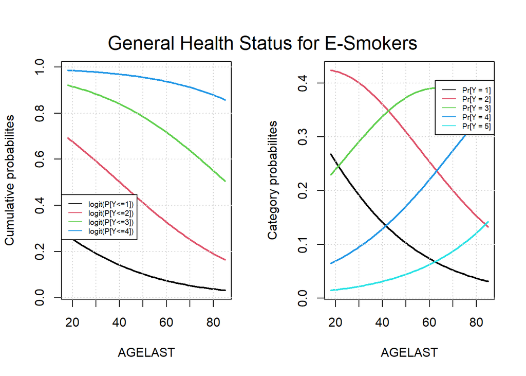

```r
# For smokers
fit <- vglm(ADGENH42 ~ AGELAST,
             family = cumulative(parallel = TRUE),
             data = smk_df)

df_pred = data.frame(AGELAST = seq(min(smk_df$AGELAST), max(smk_df$AGELAST), by = 1))
preds = predict(fit, df_pred)
cum_probabilities = t(apply(preds,1,plogis))

par(mfrow = c(1,2))
matplot(df_pred$AGELAST,cum_probabilities, lty = 1, type = "l", lwd = 2,
        ylab = "Cumulative probabilites", xlab = "AGELAST")
  grid()
legend("bottomleft",
       legend = gsub("link", "", colnames(cum_probabilities)), # remove link from labels
       col = c(1,2,3,4,5), lty = 1, cex = 0.6, xpd = TRUE,
       inset = c(0, 0.25))
category_probabilities = t(apply(cbind(0,cum_probabilities,1),1,diff))
preds = predict(fit, df_pred, type = "response") # check that they are equivalent
matplot(df_pred$AGELAST, preds, lty = 1, type = "l", lwd = 2,
        ylab = "Category probabilites", xlab = "AGELAST")
  grid()
legend("topright",
       legend = sprintf("Pr[Y = %g]", 1:5),
       col = c(1,2,3,4,5), lty = 1, cex = 0.6, xpd = TRUE,
       inset = c(0, 0.08))
mtext("General Health Status for E-Smokers", outer = TRUE, cex = 1.5, line = -3.5)
```

```r
# For not smokers
fit <- vglm(ADGENH42 ~ AGELAST,
             family = cumulative(parallel = TRUE),
             data = n_smk_df)

df_pred = data.frame(AGELAST = seq(min(smk_df$AGELAST), max(smk_df$AGELAST), by = 1))
preds = predict(fit, df_pred)
cum_probabilities = t(apply(preds,1,plogis))

par(mfrow = c(1,2))
matplot(df_pred$AGELAST,cum_probabilities, lty = 1, type = "l", lwd = 2,
        ylab = "Cumulative probabilites", xlab = "AGELAST")+
  grid()
```

```
## integer(0)
```

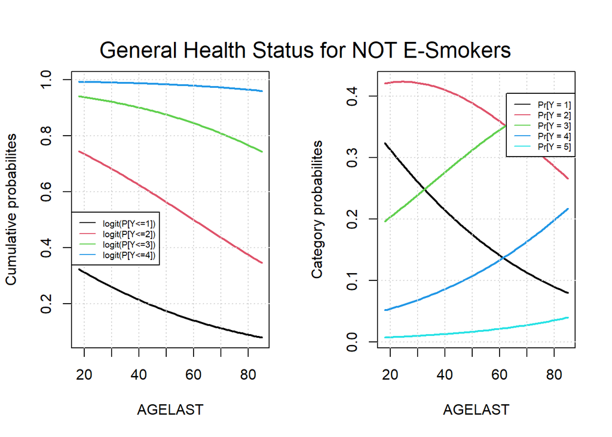

```r
legend("bottomleft",
       legend = gsub("link", "", colnames(cum_probabilities)), # remove link from labels
       col = c(1,2,3,4,5), lty = 1, cex = 0.6, xpd = TRUE,
       inset = c(0, 0.3))
category_probabilities = t(apply(cbind(0,cum_probabilities,1),1,diff))
preds = predict(fit, df_pred, type = "response") # check that they are equivalent
matplot(df_pred$AGELAST, preds, lty = 1, type = "l", lwd = 2,
        ylab = "Category probabilites", xlab = "AGELAST")
  grid()
legend("topright",
       legend = sprintf("Pr[Y = %g]", 1:5),
       col = c(1,2,3,4,5), lty = 1, cex = 0.6, xpd = TRUE,
       inset = c(0, 0.08))
mtext("General Health Status for NOT E-Smokers", outer = TRUE, cex = 1.5, line = -3.5)
```

Also in this case the results for Perceived Mental Health and General Health are quite similar to those previously discussed. A difference we can point out is a general improvement in perceived mental health for E-Smokers (compared to cigarette smokers) and a general worsening in general health for E-Smokers. One interpretation of this could be that some people are switching to E-smoking because of poor health, and what we are seeing is due to external factors or previous habits. Unfortunately, we do not have access to this type of data in this dataset, so we will limit our discussion to what we are observing.